# 1 Introduction

### 6.6.2 NAT Server Parameter Structure

This section describes a data structure that is generated automatically by the XGCONF configuration. If you are using XGCONF for configuration, you can ignore the structure described here.

The following structure defines the unique parameters of the NAT server service. It is located in the file: `/ti/ndk/inc/nettools/inc/natif.h`.

```c
//
// NAT Parameter Structure
//
typedef struct _ntparam_nat {
     uint32_t    IPVirt;   // Virtual IP address
     uint32_t    IPMask;   // Mask of virtual subnet
     uint32_t    MTU;      // NAT packet MTU (normally 1500 or 1492)
} NTPARAM_NAT;
```

- IPVirt: NAT Group virtual network address
- IPMask: Subnet mask of NAT Group virtual network
- MTU: IP MTU Limit (1500 for Ethernet, 1492 for PPPoE, etc.)

This structure is used both when specifying the service to the configuration system or when bypassing the configuration and invoking the service API directly.

### 6.6.3 Invoking the Service via NETTOOLS API

In addition to the configuration option, this service can also be created and destroyed directly through this NETTOOLS API. If an application wishes to bypass the configuration system and launch the service directly, these calls can be used.

#### NATOpen – Enable the NAT Service

```c
void *NATOpen( NTARGS *pNTA,
               NTPARAM_NAT *pNTP );
```

**Parameters**

- pNTA: Pointer to common argument structure used by all services.
- pNTP: Pointer to NAT parameter structure.

**Return Value** Returns a handle to the NAT instance (1), or NULL if the service could not be created. This handle is used with *NATClose()* to disable the service when it is no longer needed.

**Description** Enables the Network Address Translation Service. Although the function returns a handle for compatibility with the standard NETTOOLS API, only one instance of the NAT service is allowed.

This service utilizes the virtual and external network information using the configuration system. If the configuration system was not used to create the network records, this function will fail.

The NAT service executes on a specific public interface. Thus, it is compatible with NT_MODE_IFIDX only.

#### NATClose – Disable the NAT Service

```c
void NATClose( void *hNAT );
```

**Parameters**

- hNAT: Handle to NAT service obtained from *NATOpen()*

**Return Value** None.

**Description** Disables the NAT service.

# 7 Registering NDK Hook Functions

The NDK provides a function, `NDK_registerHook`, that allows the user to register their own functions to hook into predetermined internal portions of the NDK. Some NDK modules already provide their own methods of hooking into their code, but we have started to consolidate the hooks into the `NDK_registerHook` method.

## 7.1 Operation

### 7.1.1 Hook Function Structure

All user hook functions must be of the type `NDK_HookFxn` defined in `ti/ndk/inc/socketndk.h` as:

```c
typedef int (*NDK_HookFxn) (uintptr_t);
```

#### NDK_registerHook - Register a hook function

```c
void NDK_registerHook( int         type,
                       NDK_HookFxn fxn  );
```

**Parameters**

- type: The type of hook function to register. This determines where in the NDK the function will be run.
- fxn: The function to be registered

**Description** Registers a NDK_HookFxn of a given type. For instance a `CREATE_SKT_CTX_HOOK` type will register the function inside socket creation calls

## 7.2 Hook Function Types

The NDK currently supports three hook function types. The symbols for the types are displayed below, and can be found in `/ti/ndk/inc/socketndk.h`

- `CREATE_SKT_CTX_HOOK` - Create socket context
- `CLOSE_SKT_CTX_HOOK` - Close socket context
- `NETSTART_ERROR_HOOK` - NetStart Error

### 7.2.1 Create/Close Socket Context

These two types allow you to hook into the process of creating or closing a socket. Both the create and close hooks will send a `SOCKET` as an argument.

The caller of the create socket context hook expects an integer return value indicating the socket’s “context”. This context can be whatever you want it to be, but it will ultimately be stored on the `SOCK` struct’s `int32_t` `Ctx` field.

The close socket context hook is meant to remove any “context” that was created in the create socket context hook call. The caller does not expect any return value.

The NDK’s own `slnetif` module implements these hooks in `ti/ndk/slnetif/slnetifndk.c` by registering the `addSktToTable` and `removeSktFromTable` functions as open and close context hooks respectively.

### 7.2.2 NetStart Error

This type will hook into the various error states of the `NC_NetStart` function found in `ti/ndk/netctrl/netctrl.c`. This allows you to configure what action should be taken, and what information should be displayed at these error states. If this hook function is not present, default actions will be taken at error states.

The caller of this hook function will pass a `NetStartError_Obj` (definition found in `ti/ndk/inc/socketndk.h`) as an argument. The `NetStartError_Obj`’s `error` field will be filled in with the type of the error. The two currently supported error types (found in `ti/ndk/inc/stack/inc/nimuif.h`) are:

- `NIMU_ERR_SOME_FAILED` - Some NIMU devices failed to initialize during stack startup
- `NIMU_ERR_ALL_FAILED` - All NIMU devices failed to initialize during stack startup

Below is an example of how this hook function type can be used:

```c
#include <ti/ndk/inc/stkmain.h>
#include <ti/ndk/inc/netmain.h>

static int netCtrlErrorHook(uintptr_t errorStruct)
{
    NetStartError_Obj *ncError = (NetStartError_Obj *)errorStruct;

    if(ncError->error == NIMU_ERR_ALL_FAILED)
    {
        DbgPrintf("All NIMU devices failed to initialize. Shutting down stack\n");
        NC_NetStop(ncError->error);
    }
    else if(ncError->error == NIMU_ERR_SOME_FAILED)
    {
        DbgPrintf("Some NIMU devices failed to initialize. Continuing stack startup\n");
    }
    else
    {
        DbgPrintf("Unrecognized NC_NetStart error.\n");
    }

    /*
     * This hook type does not need a return value, but returning 0 to satisfy
     * the NDK_HookFxn type
     */
    return(0);
}

static void ndkStackThread(void *argUnused)
{
    NDK_registerHook(NETSTART_ERROR_HOOK, (NDK_HookFxn)(&netCtrlErrorHook));

    do
    {
        rc = NC_NetStart(hCfg, networkOpen, networkClose, networkIPAddr);
    } while(rc > 0);
}
```

# A Internal Stack Functions

In the source code to the network control functions, there are several calls to internal stack functions. This is similar to calling the kernel in other operating environments. This section contains a partial list of internal stack functions provided to aid in the comprehension of kernel oriented calls.

Note the following points for this section:

1. This section is required only for system programming that needs low level access to the stack for configuration and monitoring. **This API does not apply to general sockets application programming.**
2. In addition to the internal functions described here, there are scheduling and configurations tools available that make any direct coding to these functions unnecessary.

## A.1 Overview

The control API is the collection of functions supplied in the stack library. The entire API is exposed, although the vast majority of functions and objects will only be used internally to the stack.

### A.1.1 Interrupts and Preemption

It should be noted that no part of the stack is interrupt driven. Neither can any stack function be called at interrupt time. All interrupt processing is performed in the HAL or OS libraries, and is thus externally-defined code, which allows the development of a HAL/OS architecture that is best suited for a given operating environment, without affecting the operation of the stack.

The stack may or may not be preempted, depending on the operating environment in use. A non-preemptive architecture is possible because the stack code does not use polling loops nor make any internal blocking type calls, but preemption is also supported.

### A.1.2 Proper Use of the *llEnter()* and *llExit()* Functions

The internal stack functions are not designed to be reentrant. This allows the stack to operate freely without the concept of a critical section, which is implementation dependent and potentially detrimental to real-time operation. Thus, access to stack functions must be strictly controlled. The form of this control is dependent on the system environment, and is embodied as two low level OS library functions, *llEnter()* and *llExit()*. These functions are called before and after a section of code where any stack functions are called. For example:

```c
llEnter();
StackFunction1();
StackFunction2();
llExit();
```

These functions can be thought of as entering and exiting kernel mode.

To make normal user functions appear to be re-entrant, some user functions (like the sockets API) make internal calls to *llEnter()* and *llExit()* when calling into the stack. If an application needs to call both user functions and internal stack functions, care must be taken so that standard user functions are not called between an *llEnter()* / *llExit()* pair (this would cause an error if they in turn called *llEnter()*).

The following are good general guidelines:

- Always call *llEnter()* before calling a stack function, and *llExit()* when done calling stack functions.
- Try and keep all code that requires *llEnter()* and *llExit()* in a single module. They are only required for system maintenance.
- Do not call a normal user function (like a socket function) between an *llEnter()*/*llExit()* pair.
- Never call *llEnter()* or *llExit()* from an ISR.

### A.1.3 Objects

Many of the control API functions deal with object handles. These handles are created by a variety of class functions contained in the stack. When using an object handle, it is important to realize how the object handle will be treated by the function being called.

Associated with every object is the concept of who owns it, who is using it, and who will eventually free it. In general, when an application creates an object, the application owns it, the application is the only one using it, and the application must eventually free it. Unfortunately, the matter becomes somewhat confused when object handles are shared between applications - especially when the scope of the handle creator may be shorter than the handle itself.

In this system, there are two basic object types:

- Static Objects - The static object is one that is created by a designated task, and destroyed by that task or a task where the object has been passed. In most cases, the task that created the object also destroys it.
- Referenced Objects - A referenced object is one that may be used by other tasks after the original creator is through with it. This type of handle is useful when an object is needed for a task of indeterminate length, where the creator of the handle does not need or may not be able to track it.

  Under the referenced handle scheme, all tasks that access the object handle make a specific Ref_Xxx_() call so that references may be tracked. Whenever a task is finished with the handle, it calls the object’s de-reference function. The object is not freed until the reference count reaches zero.

## A.2 Stack Executive (Exec)

At the heart of the stack is the Executive API (Exec). The Executive acts as a message dispatcher for the internal stack components. This action is mostly hidden from the application, but there are some public functions.

### A.2.1 API Functions

#### ExecOpen – Prepare the System for Execution

```c
void ExecOpen();
```

**Description** Prepares the stack for execution by initializing the individual components. Until *ExecOpen()* is called, the system cannot do any work, but after calling this function, objects like routes and bindings can be created.

#### ExecClose – Shutdown Stack and Cleanup

```c
void ExecClose();
```

**Description** Completes stack execution. This function is called to perform final clean up on the system after all user objects (like devices and bindings) have been destroyed.

#### ExecLowResource – Signal Low Resource Condition

```c
void ExecLowResource();
```

**Description** Informs the stack that memory resources are getting dangerously low. As a result of this call, the stack will abandon certain operations that hold excessive resources. (Pending ARP packets are thrown away, IP packet fragments pending reassembly are abandoned, etc.)

#### ExecTimer – Signal 1/10th Second Timer Tick

```c
void ExecTimer();
```

**Description** This function is called ten times a second to inform the stack that one tenth of a second has elapsed. This function is called from a normal task thread, never an ISR. In theory, the function can be called from anywhere, but in practice, it is always called from a scheduler thread that also handles network packets. For more information, see the description of the NETCTRL functions in the *TI Network Developer’s Kit (NDK) User’s Guide* (SPRU523).

## A.3 Packet Buffer Manager (PBM) Object

The NDK uses a common packet buffer object that is managed by a module called the Packet Buffer Manager (PBM). The implementation of this manager determines the buffer strategy for the entire system.

Internally, the packet buffer objects are pointers to a structure of type PBM_Pkt; however, the buffers are abstracted into a handle of type PBM_Handle for use by code outside of the NDK. This helps protect the reserved members of the packet buffer structure from being misused.

If you are using XGCONF to configure your application, you can configure the size and location of the buffers managed by the PBM in the **Buffers** page of the NDK Global module configuration. See the SPRU523 (*TI Network Developer’s Kit (NDK) User’s Guide.*) and the context-sensitive help for details.

### A.3.1 Object Type

*Static* - PBM objects are owned by a single entity and destroyed by their owner. Ownership of a packet buffer changes as it is passed via function calls.

### A.3.2 API Function Overview

The PBM API functions are as follows:

**Initialization/Shutdown Functions:**

| Function | Description |
| --- | --- |
| PBM_open() | Open the Packet Buffer Manager |
| PBM_close() | Close the Packet Buffer Manager |

**Create/Destroy Functions:**

| Function | Description |
| --- | --- |
| PBM_alloc() | Create New Packet Buffer |
| PBM_free() | Destroy (Free) Packet Buffer |
| PBM_copy() | Create an exact copy of the Packet Buffer |

**Property Functions:**

| Function | Description |
| --- | --- |
| PBM_getBufferLen() | Get the length of the physical data buffer |
| PBM_getDataBuffer() | Get a pointer to the physical data buffer |
| PBM_getValidLen() | Get the length of the valid data in the buffer |
| PBM_getDataOffset() | Get the buffer offset to the start of the valid data |
| PBM_getIFRx() | Get the device handle of the ingress Ethernet device |
| PBM_setValidLen() | Set the length of the valid data in the buffer |
| PBM_setDataOffset() | Set the buffer offset to the start of the valid data |
| PBM_setIFRx() | Set the device handle of the ingress Ethernet device |

### A.3.3 API Function Description

#### PBM_open – Open the Packet Buffer Manager

```c
uint32_t PBM_open();
```

**Parameters**

- None.

**Return Value** Function returns 1 on success, and 0 on failure.

**Description** This function is called once to open the PBM module and allow it to initialize its internal queues.

#### PBM_close – Close the Packet Buffer Manager

```c
void PBM_close();
```

**Parameters**

- None.

**Return Value** None.

**Description** This function is called at system shutdown to allow the PBM module to shut down and free any memory it has allocated.

#### PBM_alloc – Create New Packet Buffer

```c
PBM_Handle PBM_alloc( uint32_t MaxSize );
```

**Parameters**

- MaxSize: Maximum size of the physical data buffer required

**Return Value** Handle to the packet buffer or NULL on memory allocation error.

**Description** This function is called to create a new packet buffer handle. When first created, the packet is entirely uninitialized, except for the physical characteristics of the data buffer (the buffer pointer and its physical length). The length of the buffer will be the same or greater than that specified by the caller in *MaxSize*.

#### PBM_free – Destroy (Free) Packet Buffer

```c
void PBM_free( PBM_Handle hPkt );
```

**Parameters**

- hPkt: Handle to packet buffer to free

**Return Value** None.

**Description** This function is called to destroy a packet buffer. When called, all objects associated with the packet buffer are dereferenced or destroyed.

#### PBM_copy – Create an exact copy of the Packet Buffer

```c
PBM_Handle PBM_copy( PBM_Handle hPkt );
```

**Parameters**

- hPkt: Handle to packet buffer to copy

**Return Value** Handle to the new copy of the packet buffer or NULL on memory allocation error.

**Description** This function makes a duplicate copy of a packet buffer. It is usually called to copy a packet to be distributed to multiple destinations, or to be sent to multiple egress devices.

#### PBM_getBufferLen – Get the Length of the Physical Data Buffer

```c
uint32_t PBM_getBufferLen( PBM_Handle hPkt );
```

**Parameters**

- hPkt: Handle to packet buffer

**Return Value** Length of the physical data buffer in bytes.

**Description** This function is called to get the length of the physical data buffer associated with the packet buffer handle. Note that the buffer length is fixed for the life of the buffer and cannot be changed.

#### PBM_getDataBuffer – Get a Pointer to the Physical Data Buffer

```c
unsigned char *PBM_getDataBuffer( PBM_Handle hPkt );
```

**Parameters**

- hPkt: Handle to packet buffer

**Return Value** Pointer to the physical data buffer.

**Description** This function is called to get a pointer to the physical data buffer associated with the packet buffer handle. Note that the physical buffer is fixed and cannot be changed.

#### PBM_getValidLen – Get the Length of the Valid Data in the Buffer

```c
uint32_t PBM_getValidLen( PBM_Handle hPkt );
```

**Parameters**

- hPkt: Handle to packet buffer

**Return Value** Byte length of the valid data stored in the packet buffer.

**Description** This function is called to get the length of the valid data currently held in the packet buffer. When a packet buffer is created, it has no valid data, so this value is initially zero.

#### PBM_getDataOffset – Get the Buffer Offset to the start of the Valid Data

```c
uint32_t PBM_getDataOffset( PBM_Handle hPkt );
```

**Parameters**

- hPkt: Handle to packet buffer

**Return Value** Byte offset from the start of the physical data buffer to the first byte of valid data.

**Description** This function is called to get the offset in bytes from the start of the physical data buffer to the first byte of valid data. When a packet buffer is created, it has no valid data, so this value is initially zero.

#### PBM_getIFRx – Get the Device Handle of the Ingress Ethernet Device

```c
void *PBM_getIFRx( PBM_Handle hPkt );
```

**Parameters**

- hPkt: Handle to packet buffer

**Return Value** NULL for locally created packets, or a handle to the device on which the packet was received.

**Description** This function is called to get the handle to the ingress device where the packet contained in the packet buffer originated. Packet drivers in the HAL (both serial and Ethernet based) record the logical handle associated with all incoming packets. This identifies the packet type as well as the interface on which the packet was received.

#### PBM_setValidLen – Set the Length of the Valid Data in the Buffer

```c
void PBM_setValidLen( PBM_Handle hPkt,
                      uint32_t   length );
```

**Parameters**

- hPkt: Handle to packet buffer
- length: Length of the valid data held in the packet buffer

**Return Value** None.

**Description** This function is called to set the length of the valid data in the packet buffer. It informs the system of the number of bytes of valid data that are stored in the physical data buffer. When a packet buffer is created, it has no valid data, so this value is initially zero.

#### PBM_setDataOffset – Set the Buffer Offset to the Start of the Valid Data

```c
void PBM_setDataOffset( PBM_Handle hPkt,
                        uint32_t   offset );
```

**Parameters**

- hPkt: Handle to packet buffer
- offset: Offset from start of data buffer to valid data

**Return Value** None.

**Description** This function is called to set the offset in bytes from the start of the physical data buffer to the first byte of valid data. It informs the system of where valid data is stored in the physical data buffer. When a packet buffer is created, it has no valid data, so this value is initially zero.

#### PBM_setIFRx – Set the Device Handle of the Ingress Ethernet Device

```c
void PBM_getIFRx( PBM_Handle hPkt,
                  void       *hDevice );
```

**Parameters**

- hPkt: Handle to packet buffer
- hDevice: Handle to packet ingress device

**Return Value** None.

**Description** This function is called to set the handle to the ingress device where the packet contained in the packet buffer originated. Packet drivers in the HAL (both serial and Ethernet based) record the logical handle associated with all incoming packets. This identifies the packet type, as well as the interface on which the packet was received.

## A.4 Packet Buffer Manager Queue (PBMQ) Object

The PBM module also includes a queue object that can be used to queue packet buffers for later use. The queue is a first in first out system, so it can be used to queue in-order packets as well as free buffers.

The PBMQ object is just a structure of type PBMQ. Once this structure is declared and initialized, it is ready for use.

### A.4.1 Object Type

*Static* - PBMQ objects are owned by a single entity and destroyed by their creator.

### A.4.2 API Function Overview

The PBM API functions are as follows:

| Function | Description |
| --- | --- |
| PBMQ_init() | Initialize a PBMQ object for use |
| PBMQ_count() | Return the number of PBM packet buffers on the queue |
| PBMQ_enq() | Enqueue a PBM packet buffer onto the queue |
| PBMQ_deq() | Dequeue a PBM packet buffer off the queue |

### A.4.3 API Function Description

#### PBMQ_init – Initialize a PBMQ Object for Use

```c
void PBMQ_init( PBMQ *pQ );
```

**Parameters**

- pQ: Pointer to a structure of type PBMQ

**Return Value** None.

**Description** This function is called once to initialize a PBMQ structure for use.

#### PBMQ_count – Return the Number of PBM Packet Buffers on the Queue

```c
uint32_t PBMQ_count( PBMQ *pQ );
```

**Parameters**

- pQ: Pointer to a structure of type PBMQ

**Return Value** Number of queued buffers.

**Description** This function is called once to return the number of PBM packet buffers currently on the indicated queue.

#### PBMQ_enq – Enqueue a PBM Packet Buffer onto the Queue

```c
void PBMQ_enq( PBMQ       *pQ,
               PBM_Handle hPkt );
```

**Parameters**

- pQ: Pointer to a structure of type PBMQ
- hPkt: Handle to PBM packet buffer to add to queue

**Return Value** None.

**Description** This function is called to add the supplied PBM packet buffer to the indicated queue.

#### PBMQ_deq – Dequeue a PBM Packet Buffer Off the Queue

```c
PBM_Handle PBMQ_deq( PBMQ *pQ );
```

**Parameters**

- pQ: Pointer to a structure of type PBMQ

**Return Value** Handle to PBM packet buffer, or NULL on empty queue.

**Description** This function is called to remove a PBM packet buffer from the indicated queue. The function returns a handle to the PBM packet buffer removed from the queue, or NULL if the queue was empty.

## A.5 Jumbo Packet Buffer Manager (Jumbo PBM) Object

The PBM object is capable of handling memory allocations only up to buffer sizes of maximum MMALLOC_MAXSIZE (3068 bytes). For handling memory allocation for jumbo frames, i.e., packets typically larger than 1500 bytes in size, and that could be as large as 10K bytes, the PBM object invokes the Jumbo PBM APIs internally. The Jumbo PBM is responsible for handling memory allocation and de-allocation for Jumbo frames.

The following are some of the main features of Jumbo PBM:

- The Jumbo PBM implementation is similar to the PBM implementation, except that it can handle larger block sizes than the ones in PBM and ranges between 3K and 10K bytes by default.
- Jumbo PBM does not use any TI-RTOS Kernel APIs or dynamic memory allocation method for its memory allocation and, therefore, can be used safely in interrupt context. It uses a static memory allocation method, i.e., it reserves a chunk of memory in the *far* section of the device memory and uses it to allocate for the packet buffers required.
- The Jumbo PBM allocates memory off a separate section in the memory than the PBM. The PBM uses the memory sections *NDK_PACKETMEM*, *NDK_MMBUFFER* for its memory allocation. On the other hand, Jumbo PBM defines and uses a section called *NDK_JMMBUFFER* for its memory allocation. The size of this section and its placement are all customizable by an application user.
- A sample implementation of the Jumbo PBM is provided in the NDK OS abstraction layer (OS AL). The customer is expected to customize this implementation according to their application needs and system’s memory constraints. The memory section sizes, block sizes, and the allocation method is all up for customization.
- Jumbo PBM APIs are not expected to be invoked directly. The application and driver must call the *PBM_alloc()*/*PBM_free()* APIs only. These APIs in turn invoke the Jumbo PBM APIs to allocate/clean-up memory if the memory requested is larger than what PBM can handle, i.e., 3K bytes.

For a sample implementation of the Jumbo PBM, refer to the source file `/ti/ndk/stack/jumbo_pbm.c`.

### A.5.1 API Function Overview

The Jumbo PBM API are as follows:

| Function | Description |
| --- | --- |
| _jumbo_mmInit() | API to initialize the Jumbo PBM object |
| jumbo_mmAlloc() | Allocates memory requested for the new packet buffer |
| jumbo_mmFree() | Frees up the memory held in the packet buffer |
| _jumbo_mmCheck() | Dump the current memory usage in Jumbo PBM object |

### A.5.2 API Function Description

#### _jumbo_mmInit – Initialize the Jumbo PBM object for use.

```c
int _jumbo_mmInit();
```

**Parameters**

None

**Return Value** Always returns 1 to indicate success.

**Description** This function is called during the system initialization to initialize the Jumbo PBM memory and any relevant data structures.

#### jumbo_mmAlloc – Allocate a new Jumbo packet buffer.

```c
void *jumbo_mmAlloc( uint32_t Size );
```

**Parameters**

- Size: Size of the packet buffer to allocate.

**Return Value** Pointer to the newly allocated packet buffer.

**Description** This function is called by the PBM object when an application/driver requests for a packet buffer larger than what it can handle, i.e., MMALLOC_MAXSIZE (3068 bytes). This API allocates memory out of jumbo memory pool and returns a pointer to the packet buffer just allocated.

#### jumbo_mmFree – Frees up memory held by the packet buffer.

```c
void jumbo_mmFree( void *p );
```

**Parameters**

- p: Handle to the packet buffer that was obtained earlier using jumbo_mmAlloc API and that needs to be freed up.

**Return Value** None

**Description** This API returns the packet buffer to the jumbo memory pool for use again by the application. The packet buffer handle passed as an argument to this function must be a valid handle obtained using *jumbo_mmAlloc()* API earlier.

#### _jumbo_mmCheck – Dumps the memory usage stats for jumbo PBM object.

```c
void _jumbo_mmCheck( uint32_t CallMode,
                     int (*pPrn)(const char *,...) );
```

**Parameters**

- CallMode: Specifies the type of stats that need to be printed out. The 3 supported call modes are:
  - MMCHECK_MAP: Map out allocated memory, but don’t dump IDs
  - MMCHECK_DUMP: Dump allocated block IDs
  - MMCHECK_SHUTDOWN: Dump all allocated blocks and free
- pPrn: Callback function pointer to be notified

**Description** This function iterates through the Jumbo PBM object’s memory allocation table and dumps the current memory usage stats according to the arguments specified.

## A.6 Stack Event (STKEVENT) Object

Although technically not part of the NDK, the STKEVENT event object is a central component to the low level architecture. It ties the HAL layer to the network scheduler thread. The network scheduler thread waits on events from various device drivers in the system including the Ethernet, serial, and timer drivers. The device drivers use the STKEVENT object to inform the scheduler that an event has occurred.

### A.6.1 Object Type

*Static* - The STKEVENT object is created and owned by the network scheduler.

### A.6.2 API Function Overview

The STKEVENT object is implemented entirely via #define MACROs and therefore, does not have a true API. This allows the network scheduler to present an abstracted API to the HAL layer for network events. The STKEVENT object is a simple structure and manipulated directly by the network control module (NETCTRL). This is discussed further in the *TI Network Developer’s Kit (NDK) User’s Guide* (SPRU523).

The two MACRO functions are as follows:

**Property Functions:**

| Function | Description |
| --- | --- |
| STKEVENT_init() | Initialize a new STKEVENT object to NULL |
| STKEVENT_signal() | Signal a new STKEVENT event code |

### A.6.3 API Function Description

#### STKEVENT_init – Initialize a new STKEVENT object to NULL

```c
void STKEVENT_init( STKEVENT_Handle  hEvent,
                    Semaphore_Handle hSem )
```

**Parameters**

- hEvent: Handle to STKEVENT object
- hSem: Handle to Semaphore object to use in STKEVENT (if any)

**Return Value** None.

**Description** This function is called once to initialize the STKEVENT object so it is ready for use.

> **NOTE:** This function is implemented as a multi-line macro, so care should be taken when using it in the body of an if/else statement.

#### STKEVENT_signal – Signal a New STKEVENT Event Code

```c
void STKEVENT_signal( STKEVENT_Handle hEvent,
                      uint32_t        EventCode,
                      uint32_t        fHwAsynch )
```

**Parameters**

- hEvent: Handle to STKEVENT object
- EventCode: Type of event being signaled
- fHwAsynch: Flag indicating event triggered by an asynchronous hardware event (e.g., ISR, PRD).

**Return Value** None.

**Description** This function is called from a device driver to signal an event to the network scheduler for further processing. The STKEVENT handle *hEvent* is an event handle supplied to the device driver when the driver is first initialized. The *EventCode* parameter specifies the type of event. The defined events include the following:

- STKEVENT_TIMER: 100 ms Timer Tick Event
- STKEVENT_ETHERNET: One or more Ethernet packets received
- STKEVENT_SERIAL: One or more serial packets received
- STKEVENT_LINKUP: Link has come up
- STKEVENT_LINKDOWN: Link has gone down

The *fHwAsynch* flag specifies whether the event was triggered by an external asynchronous hardware source. Examples of asynchronous events include hardware interrupts or timer PRDs. An example of a non-asynchronous event would be detecting an event from within a driver service check function. Service check functions are called periodically (or polled) by the scheduler.

> **NOTE:** This function is implemented as a multi-line macro, so care should be taken when using it in the body of an if/else statement.

## A.7 Link Layer Information (LLI) Object

To make full use of the stack objects described in this section, it is necessary to understand some of the stack’s basic building block components. One such component is the Link Layer Information Object, or LLI for short.

An LLI object is an ARP table entry. This implementation of the IP stack combines the traditional route table and ARP table into a single table with a single API. Routes that need to use the ARP function include an ARP status object, called LLI. Normally, you only use an LLI object to inspect the ARP status of the route table.

The ARP entries can be of two types:

- **Dynamic:** These ARP entries are managed using the Address Resolution Protocol (ARP), i.e., through exchange of ARP Request and ARP Reply messages between the NDK stack and the networking device engaged in communication with it. These entries are dynamic and have a keep-alive timeout associated with them. An ARP/LLI entry’s lifetime is extended using *ARP revalidation logic* if it has been active, i.e., if it has been used by an application in the system in the last ARP inactivity timeout seconds. These keep-alive and ARP inactivity timeouts are configurable in NDK and can be tuned as per the application and system needs. However, if the ARP entry was inactive or idle, or if the ARP revalidation process failed, the ARP entry is deleted and the communication between the NDK stack and the networking device in question is broken unless it is re-established using ARP protocol again. To configure a dynamic ARP entry, the NDK stack internally uses the *LLIValidateRoute()* API. This API is documented in the following section.
- **Static:** On the other hand, static entries are ARP entries that are manually configured by an application in the stack and they have no timeout associated with them. They remain valid until the application or user deletes them. No ARP request-reply transactions are performed here.

Both the dynamic and static ARP entries are supported in NDK stack. The next section discusses the APIs exported by NDK stack to configure dynamic and static ARP entries.

### A.7.1 ARP Revalidation Logic

Each dynamic LLI/ARP entry in NDK is associated with a non-zero *Keep-alive timeout* (controlled using CFGITEM_IP_RTKEEPALIVETIME). This timeout determines the length of time in seconds that an LLI entry and its associated route entry is valid. The routing module in the stack internally runs a timer and periodically checks to see if any routes or associated LLI entries are about to expire. If it finds a route/LLI entry that is about to expire, it checks to see if that LLI entry is *active*, i.e., if it has been used in the last *Route Inactivity timeout* seconds (configured using CFGITEM_IP_RTARPINACTIVITY). If so, the LLI module initiates an *ARP Request/Reply* exchange to revalidate the LLI entry even before it expires and disrupts any ongoing communication. If an ARP reply is received successfully for the request sent out earlier, the LLI entry is marked *valid* again for another *Keep-alive timeout* seconds and any packets using the route/LLI entry are sent out of the device. However, if no ARP reply is received, the ARP request is retransmitted and this process is repeated 3 times before the revalidation process is aborted and the associated LLI/Route entries are deleted. Also, if the LLI/Route entry was inactive or never used in the last *Route Inactivity Timeout* seconds ARP revalidation process is not done for such an entry and is deleted immediately from the system. Once the LLI/Route entries are deleted they have to be re-established using a successful *ARP Request-Reply* exchange triggered by an application’s attempt to transmit packets to the intended destination.

### A.7.2 Object Type

*Static* - LLI objects are owned and destroyed by their creator.

### A.7.3 Information Structure

The following data structure is used to hold information regarding an ARP/LLI entry in the NDK stack. This structure is especially useful in presenting the LLI entry info in a simple, compact way to an application requesting information about the LLI entries configured in the stack.

```c
/**
 * @brief
 *  This structure describes the LLI/ARP Information Object.
 *
 * @details
 *  This data structure is used by the LLI module to populate
 *  LLI/ARP Entry information contained in the NDK Kernel
 *  in a simple, user-friendly way to the application.
 *
 */
typedef struct _lli_info
{
    /**
     * @brief Links to other LLI_INFO Objects
     */
    LIST_NODE Links;

    /**
     * @brief Boolean Flag to indicate whether this LLI
     * entry is a static / dynamic entry.
     */
    unsigned char     IsStatic;

    /**
     * @brief The 4 byte IPv4 address associated with this
     * LLI/ARP Entry.
     */
    uint32_t       IPAddr;

    /**
     * @brief The 6 byte Ethernet MAC address associated with this
     * LLI/ARP Entry.
     */
    unsigned char     MacAddr[6];
} LLI_INFO;
```

### A.7.4 API Function Overview

The LLI API functions are as follows:

| Function | Description |
| --- | --- |
| LLIGetMacAddr() | Get the Mac Address Associated with this LLI. |
| LLIValidateRoute() | Validate an IP address/MAC address pairing in the route table. |
| LLIAddStaticEntry | Add a new static ARP entry/update an existing static ARP entry/modify a dynamic entry to a static ARP entry in the stack. |
| LLIRemoveStaticEntry | Remove a previously configured static ARP entry from the stack. |
| LLIGetStaticARPTable | Retrieve a copy of the static ARP table from the stack. |
| LLIFreeStaticARPTable | Cleans the memory allocated by a previous call to LLIGetStaticARPTable API. |

### A.7.5 API Functions

#### LLIGetMacAddr – Get the Mac Address Associated with this LLI

```c
uint32_t LLIGetMacAddr( void          *hLLI,
                        unsigned char *pMacAddr,
                        uint32_t      MaxLen );
```

**Parameters**

- hLLI: Handle to LLI object
- pMacAddr: Pointer to buffer to write Mac address data
- MaxLen: Maximum byte length of buffer (must be at least 6)

**Return Value** Returns 1 if the Mac address for the LLI is valid and it was successfully written to the supplied buffer.

Returns 0 if the LLI does not contain a valid Mac address, or one of the calling parameters is invalid.

**Description** This function is called to return the six byte Mac address associated with the LLI. It is used in system programming to obtain the hardware address from an LLI contained in a route entry.

#### LLIValidateRoute – Validate an IP Address/MAC Address Pairing in the Route Table

```c
void *LLIValidateRoute(void          *hIF,
                       uint32_t      IPAddr,
                       unsigned char *MacAddr );
```

**Parameters**

- hIF: Handle to the interface on which the target IP address/MAC address appears
- IPAddr: IP address to validate
- MacAddr: Six byte MAC address corresponding to the supplied IP address

**Return Value** Referenced handle to route or NULL if there was no room to create the entry.

**Description** This function is called to create or update an entry in the stack route table for the supplied IP address. The entry for the given IP address is marked as valid, and assigned the supplied MAC address. Packets sent to the IP address will be assigned the given MAC address, and no ARP request will be sent.

This function also updates the route in the LLI (ARP) expiration list. It allows an application to change the state of the ARP entry even if the stack has already created the route. It should be used when it is unclear if the route (really ARP table entry) already exists or not.

Note that this function returns a referenced route handle. This handle must be dereferenced using the *RtDeRef()* function when it is no longer required. Because the route is treated as a standard ARP entry (with a standard expiration time as supplied in the configuration structure), the route can be dereferenced immediately.

#### LLIAddStaticEntry – Add/update a static ARP entry or change a dynamic entry to a static ARP entry

```c
int LLIAddStaticEntry( uint32_t      IPAddr,
                       unsigned char *pMacAddr );
```

**Parameters**

- IP Address: IPv4 address of the device
- pMacAddr: 6 byte EMAC address of the device corresponding to the supplied IPv4 address.

**Return Value** Returns 0 on success or -1 on invalid input/error in LLI entry creation.

**Description** This API validates the input and returns an error (-1) if any of the following conditions are met:

- No MAC Address specified
- IPv4 address specified is either a broadcast/multicast address
- IPv4 address specified is a local IP address, i.e., the IP address specified is in use by a local interface attached to the NDK stack.
- IPv4 address is not reachable using the routes configured. That is, there is no Network / Cloning route (no local interface is on the same subnet as specified IPv4 address) that can be used to reach the IPv4 address specified.
- Memory allocation issue.

If no error encountered, this API does the following:

- Tries to find a duplicate static entry matching the IP Address Specified. If a duplicate static entry found, updates the entry with the new MAC address specified. Returns Success (0).
- Checks for any dynamic LLI/route entries matching the IPv4 address. If found, deletes this entry and creates a new static LLI entry and host route with the IPv4 address and new MAC address specified. Returns Success (0). This ensures that Static LLI entries always override the dynamic ones automatically configured by the stack.
- If no duplicate static/dynamic entry already exists, adds a new static LLI entry and an associated Host route to the stack using the IPv4 address and MAC address specified. Returns Success (0). The static LLI entries have to be removed by an application manually if not in use or will be deleted when the NDK stack is shutdown.

This API is an *application level* API and can be called from outside the kernel mode.

#### LLIRemoveStaticEntry – Remove a previously configured static ARP entry from the stack.

```c
int LLIRemoveStaticEntry( uint32_t IPAddr );
```

**Parameters**

- IPAddr: IPv4 address of the device

**Return Value** Returns 0 on success or -1 on invalid input/error in LLI entry removal.

**Description** This API searches for a static route and associated LLI entry in the NDK stack using the IPv4 address specified and if no entry found returns an error, i.e., -1. If a valid entry is found, it removes the route and corresponding LLI entries and cleans up any memory associated with them. On successful clean up, returns 0. If this API is not explicitly called to remove a previously configured static ARP entry, it is cleaned up only during the NDK stack shutdown.

This API is an *application level* API and can be called from outside the kernel mode.

#### LLIGetStaticARPTable – Retrieve a copy of the static ARP table from the stack.

```c
void LLIGetStaticARPTable( uint32_t*  pNumEntries,
                           LLI_INFO** pStaticArpTable );
```

**Parameters**

- pNumEntries: Pointer to hold the number of static ARP entries in the stack.
- pStaticArpTable: Pointer to hold the replicated static ARP table returned by this API

**Return Value** Updates *pNumEntries* with the number of static ARP Entries and *pStaticArpTable* with a list of LLI_INFO structures containing the information of all static ARP entries configured in the stack.

**Description** This API can be used to retrieve the number of static ARP entries and a replicated list of such entries configured in the system. This API traverses through the route and LLI (ARP) table configured in NDK, finds any static routes/LLI entries configured, and creates a copy of them and returns them as a linked list of LLI_INFO structures for the requesting application to use. In case of a memory allocation error or if no static ARP entries found, this API returns the number of entries (pNumEntries) as zero to indicate the same.

This API is an *application level* API and can be called from outside the kernel mode.

#### LLIFreeStaticARPTable – Cleans the memory allocated by a previous call to LLIGetStaticARPTable API.

```c
void LLIFreeStaticARPTable( LLI_INFO* pStaticArpTable );
```

**Parameters**

- pStaticArpTable: This is the head of the duplicated static ARP table list which has to be cleaned up

**Return Value** None

**Description** This function is called to clean the memory allocated by a previous call to LLIGetStaticARPTable API. This function cleans the replicated copy of the static ARP table.

This API is an *application level* API and can be called from outside the kernel mode.

## A.8 Binding Object

For a device object to live on the network, it must have an IP address and knowledge of its IP subnet. The process of assigning an IP address and subnet to a device binds the device with the desired IP addressing.

### A.8.1 Object Type

*Static* - Binding objects are generally created and destroyed by the same entity.

### A.8.2 BIND API Functions

Although the Bind object API is larger than that discussed here, this section covers the portion of the API that is encountered by a system application.

#### BindNew – Create New IP Binding

```c
void *BindNew( void     *hIF,
               uint32_t IPAddr,
               uint32_t IPMask );
```

**Return Value** Returns a handle to the Bind object, or NULL on error.

**Description** Binds the indicated IP address and mask to the supplied Ether device. The handle to the Ether device object is specified as hIF - or an handle to an *interface*, because the interface may or may not be an Ethernet device (but always is in this version).

The IP address and mask arguments are given the type uint32_t. The IP data must be supplied in network format. If unsure of the network format for your hardware, use the htonl() macro function on the native format (where 1.2.3.4 = = 0x01020304).

#### BindFree – Destroy IP Binding Object

```c
void BindFree( void *hBind );
```

**Description** Destroys the indicated Bind object, and frees its associated memory. This function removes the IP address and subnet association in the system route table. It has no effect on the Ether object involved in the binding.

#### BindGetFirst – Start Enumeration of Binding Objects

```c
void *BindGetFirst();
```

**Description** Returns a handle to the first binding installed in the system (or NULL if no bindings exist).

#### BindGetNext – Continue Enumeration of Binding Objects

```c
void *BindGetNext( void *hBind );
```

**Description** Returns a handle to the binding in the installed binding list that follows the indicated binding (or NULL if no more bindings exist). Note that bindings are not internally kept in chronological order in which they were installed.

#### BindGetIF – Get the Ether Object that is Bound by this Binding Object

```c
void *BindGetIF( void *hBind );
```

**Description** Returns a handle to the Ether object that is bound by this binding object. Note that a binding is nothing more than an assignment of an Ether object to an IP address/network.

#### BindGetIP – Get the IP Address/Network that is Bound by this Binding Object

```c
void BindGetIP( void     *hBind,
                uint32_t *pIPHost,
                uint32_t *pIPNet,
                uint32_t *pIPMask );
```

**Description** Returns the IP address and mask as requested by the calling arguments. Any of the pointer arguments can be NULL if the information is not required.

The arguments are defined as follows:

- pIPHost: Pointer to the local IP address assigned by this binding
- pIPNet: Pointer to the network assigned by this binding (IP address AND IP Mask)
- pIPMask: Pointer to the subnet mask of the network assigned by this binding

## A.9 Route Object

The route manager maintains IP routing information. It is called by various routines to get and set route information. A route object is a destination on the network. Locally, it consists of an egress interface and a next hop IP address.

This section describes a subset of the route object. Flags, features, and API calls have been omitted for simplicity. Also, documenting the entire API would require the documentation of other stack objects that are not covered in this document.

### A.9.1 Object Type

Referenced - Route objects are referenced and dereferenced as needed. The object is removed when the reference count reaches ZERO.

### A.9.2 Route Entry Flags Definition

Associated with each route is a collection of entry/status flags. These flags indicate the type of route and its status. Most system programming is not concerned with the route entry flags. They are listed here for completeness. The definition of the various flags is as follows:

- FLG_RTE_UP - Entry is up

  When set, indicates that the route is valid. The only time this flag is cleared is when the route is being initialized, or when an error condition is signaled via RtSetFailure(). The flag is reset to TRUE by calling *RtSetFailure()* with NULL failure code, or if the route is modified.
- FLG_RTE_EXPIRED - Entry is expired

  When set, indicates that the route is expired. The flag cannot be cleared. A new route must be created. Expired routes are never found, but a route cached by another entity may expire while it is being held.
- FLG_RTE_STATIC - Entry is static

  This flag is set when a route should remain in the routing table even if it has no references. Various routes can be static. Static routes are manually referenced by the system during create, and manually de-referenced by the system during system shutdown.
- FLG_RTE_BLACKHOLE - Entry is a blackhole

  When set, indicates that the route is a black hole. All packets destined for this address are silently discarded.
- FLG_RTE_REJECT - Entry is rejected When set, indicates that the route is to an invalid address. All packets destined for this address are discarded with an error indication.
- FLG_RTE_MODIFIED - Route has been auto modified

  When set, indicates that the route has been modified as a result of an ICMP redirect message. This can occur only to GATEWAY routes, and only if ICMP modifications are enabled in the stack configuration.
- FLG_RTE_DYNAMIC - Route has been auto created

  When set, indicates that the route has been created as a result of an ICMP redirect message. ICMP can only create GATEWAY routes, and may do so only if ICMP modifications are enabled in the stack configuration.
- FLG_RTE_PROXYPUB - Reply to ARP with client’s MAC address

  This flag indicates that the router is a proxy publisher of another entity’s MAC address. When set, the ARP protocol will respond to ARP requests for the route’s IP address with the supplied static MAC address when the host is on the same IF device as the incoming ARP request. This allows support of hosts that do not implement ARP but are on the same physical Ethernet network. PROXYPUB entries are always created with a MAC address and contain a static LLI (link-layer info, i.e., ARP entry).
- FLG_RTE_PROXY - Reply to ARP with router’s MAC address

  This flag indicates that the router is acting as a proxy for this host or network route. When set, the ARP protocol will respond to ARP requests with its own MAC address for the associated IP host or network when the network appears on a different IF device from the incoming ARP request. The MAC address supplied in the reply is the local MAC of the ingress IF device. This technique tricks clients into sending packets to the router when subnets are split across physical devices on a router.

  One potential use applies when the stack is acting as a PPP server and Ethernet router. If a PPP client is made part of the same IP subnet as an Ethernet based interface, the stack acts as the PPP client’s proxy so that Ethernet peers can communicate via ARP.
- FLG_RTE_CLONING - Cloning route to a local IP subnet

  When set, indicates that the network route is a cloning route. Cloning routes clone (spawn to) host routes when a route search is performed on a host address that is a member of the cloning route’s network (via the address and subnet mask). Cloned host routes take on most of the properties of their parent network route, with the following alterations:
  - Any MODIFIED or DYNAMIC flags are cleared.
  - The STATIC flag is never set.
  - The HOST flag is set and the netmask is set to 1s.
  - The CLONING flag is cleared.

  > **NOTE:** Cloning routes are routes to a network (IP and subnet). These routes are added automatically when an IP network is added to a device via a Bind object. Take care when adding this type of route manually.
- FLG_RTE_HOST - Host route (no subnet mask)

  When set, indicates that the route entry is a host route. A host route has no subnet mask (or rather a subnet mask of all 1’s). When searching for a route, host routes always match before network routes (but this behavior can be overridden).
- FLG_RTE_GATEWAY - Destination is available via a Gateway

  When set, indicates that the host or network route is indirectly accessible via an IP gateway. For a route with this flag set, the GateIP address is always valid. Most GATEWAY routes will also be network routes; however, a host redirect from ICMP can create a host route with a different gateway than its parent route. When searching for a route, gateway routes always match before host routes (but this behavior can be overridden).
- FLG_RTE_IFLOCAL - IP address is Local to the stack

  When set, indicates that the host route does not have a valid LLI (ARP) entry because the host is local to the stack. The MAC address of this local IP host address can be obtained from the interface handle associated with the route.

  > **NOTE:** Local routes are in the routing table to route packets that originate in the stack’s upper layers. When handling ARP requests and routing of incoming packets from outside the stack, the IP address list published via the Bind object is used. The ARP will not respond to, nor will the IP accept, packets addressed to an IP address that is not in the Bind list, even if an IFLOCAL address entry exists in the route table. As with a cloning route, the Bind object is the best way to create a local route.

### A.9.3 Route Entry Flags Guidelines

See the following for some general guidelines to use when creating new routes. Use the definitions listed above with the following legal flag combinations:

- Setting FLG_RTE_BLACKHOLE
  - FLG_RTE_REJECT - must be OFF
- Setting FLG_RTE_REJECT
  - FLG_RTE_BLACKHOLE - must be OFF
- Setting FLG_RTE_CLONING
  - FLG_RTE_HOST - must be OFF
  - FLG_RTE_GATEWAY - must be OFF
  - FLG_RTE_IFLOCAL - must be OFF
- Setting FLG_RTE_HOST
  - FLG_RTE_CLONING - must be OFF
- Setting FLG_RTE_GATEWAY
  - FLG_RTE_CLONING - must be OFF
  - FLG_RTE_IFLOCAL - must be OFF
- Setting FLG_RTE_IFLOCAL
  - FLG_RTE_HOST - must be ON
  - FLG_RTE_CLONING - must be OFF
  - FLG_RTE_GATEWAY - must be OFF
- Setting FLG_RTE_PROXYPUB
  - FLG_RTE_HOST - must be ON
  - FLG_RTE_CLONING - must be OFF
  - FLG_RTE_GATEWAY - must be OFF
- Setting FLG_RTE_PROXY
  - FLG_RTE_CLONING - must be OFF
  - FLG_RTE_GATEWAY - must be OFF

### A.9.4 API Functions

The Route API is the most extensive API that a system task uses outside of the stack routines themselves. As with the other stack APIs, this guide does not document the entire API.

Calls that accept a CallFlags argument can be supplied with the FLG_RTF_REPORT flag to indicate that the call should result in a route report to the route control object. The route control object is described later in this section.

#### RtRef – Reference a Route

```c
void RtRef( void *hRt );
```

**Description** Called to add one to the reference count of a route. An application that keeps a route it did not create itself should reference the route before it uses it, and dereference it when it is through.

#### RtDeRef – Dereference a Route

```c
void RtDeRef(void *hRt);
```

**Description** Called to remove one from the reference count of a route. An application dereferences a route when it is through with it. This is the same (to the application) as destroying the route. The route is actually destroyed when its reference count reaches zero.

#### RtCreate – Create New Route

```c
void *RtCreate( uint32_t      CallFlags,
                uint32_t      RtFlags,
                uint32_t      IPAddr,
                uint32_t      IPMask,
                void          *hIF,
                uint32_t      IPGateway,
                unsigned char *pMacAddr );
```

**Parameters**

- CallFlags: Call Type Flags
- RtFlags: Route Type Flags
- IPAddr: Destination IP address of route
- IPMask: Destination IP Mask of route (or NULL)
- hIF: Interface (or NULL)
- IPGateway: Gate IP address (or NULL)
- pMacAddr: Pointer to six byte MAC address (or NULL)

**Call Flags**

- FLG_RTF_REPORT: Reports new route (NEW)

**Return Value** Referenced handle to newly created route.

**Description** Called to create a new host or network route and add it to the route table. Existing routes cannot be modified via this call.

Some flag combinations are incorrect, and the following rules are strictly enforced.

- FLG_RTE_UP flag is always SET.
- FLG_RTE_EXPIRED and FLG_RTE_MODIFIED flags are always CLEARED.
- If FLG_RTE_HOST is set, then the route is a host route and *IPMask* is ignored, and FLG_RTE_CLONING cannot be set.
- If FLG_RTE_GATEWAY is set, then *IPGateway* must specify a valid (reachable) IP address.
- If FLG_RTE_GATEWAY is not set, then *hIF* must be valid.
- If FLG_RTE_IFLOCAL is set, then the specified host address is local to this machine, and FLG_RTE_HOST must also be set, FLG_RTE_GATEWAY cannot be set, and *hIF* must be valid.
- If FLG_RTE_CLONING is specified in Flags, the route is a cloning network route. The *IPMask* argument must be valid, and neither FLG_RTE_HOST nor FLG_RTE_GATEWAY may be set.
- If FLG_RTE_STATIC is specified in Flags, the route is referenced once by the route code, and later dereferenced during shut down.

#### RtFind – Find a Route

```c
void RtFind( uint32_t CallFlags,
             uint32_t IPAddr );
```

**Call Flags**

- FLG_RTF_REPORT: Reports any new (cloned) or unfound route (NEW or MISS)

**Return Value** Referenced handle to best match route (or NULL)

**Description** This call searches the route table for a route that matches the supplied IP address. The search always returns the best match for a route. The best match is a match with the most bits in the subnet mask. Thus, a host match takes priority over a network match.

When there is more than one route with the same subnet mask, the following matching guidelines are used (listed from best to worst):

- Route has a local destination (occurs with host addresses only).
- Route has a gateway destination.
- Route has a subnet destination on a connected interface.

Sometimes a search is desired where particular matches are desired. The following flags can be combined with the value of *CallFlags* to change the behavior of the search:

- FLG_RTF_CLONE: Clone a network route to a host route if host not found
- FLG_RTF_HOST: Find only non-gateway host routes

#### RtSetTimeout – Set the Timeout for a Non-static Route

```c
void RtSetTimeout(void *hRt, uint32_t dwTimeOut);
```

**Description** This call allows an application to specify that the stack should time out a referenced route. When the route is added to the timeout list, the system will add a reference. Thus, once the application sets the timeout value, it should call *RtDeRef()* to dereference the route. The route will stay valid until the timeout value is exceeded, after which it is dereferenced by the system. Note that if this function is called and the route is not dereferenced by the caller, it will still be removed from the system route table when the expiration time elapses, but the object will not be freed.

#### RtSetFailure – Set the Timeout for a Non-Static Route

```c
void RtSetFailure( void     *hRt,
                   uint32_t CallFlags,
                   uint32_t FailCode );
```

**Call Flags**

- FLG_RTF_REPORT: Reports the status change of the route (UP or DOWN)

**Description** This call allows an application to specify a particular error with a route, or clear a previously indicated error. Setting an error clears the FLG_RTE_UP bit in the flags. When use of the route is attempted, the specified error is returned. Defined error codes for the *FailCode* argument are:

- NULL: Route is operating normally (sets FLG_RTE_UP flag)
- RTC_HOSTDOWN: Host is down
- RTC_HOSTUNREACH: Host unreachable
- RTC_NETUNREACH: Network unreachable

#### RtRemove – Remove Route from System Route Table

```c
void RtRemove( void     *hRt,
               uint32_t CallFlags,
               uint32_t FailCode);
```

**Call Flags**

- FLG_RTF_REPORT: Reports the removal of the route (REMOVED)

**Description** This call allows an application to remove a route from the system route table independently of any held references to the route. It is similar to the *RtSetFailure()* call, but differs in two ways:

1. It removes the route from the system route table so that it can no longer be returned by *RtFind()*.
2. It calls the IP and Sockets layers to flush the route from any local cache.

Calling this function clears the FLG_RTE_UP bit in the flags. When use of the route is attempted, the error specified in *FailCode* is returned. Defined error codes for the *FailCode* argument are:

- RTC_HOSTDOWN: Host is down
- RTC_HOSTUNREACH: Host unreachable
- RTC_NETUNREACH: Network unreachable

#### RtGetFailure – Get the Error Code of a Downed Route

```c
uint32_t RtGetFailure(void *hRt);
```

**Return Value** Failure code or NULL for normal operation.

**Description** This call allows an application to retrieve the error code of a route where the FLG_RTE_UP bit is not set in the route flags. Defined error codes are:

- RTC_HOSTDOWN: Host is down
- RTC_HOSTUNREACH: Host unreachable
- RTC_NETUNREACH: Network unreachable

#### RtGetFlags – Get the Route Flags

```c
uint32_t RtGetFlags(void *hRt);
```

**Description** This function returns the state of the route flags for the indicated route. The flag values and definitions were discussed earlier in this section.

#### RtGetIPAddr – Get the Route IP Address

```c
uint32_t RtGetIPAddr(void *hRt);
```

**Return Value** IP host/network address.

**Description** This function returns the specified route’s IP address in network format.

#### RtGetIPMask – Get the Route IP Subnet Mask

```c
uint32_t RtGetIPMask(void *hRt);
```

**Return Value** IP subnet mask.

**Description** This function returns the specified route’s IP subnet mask in network format.

#### RtGetGateIP – Get the Route Gateway IP Address

```c
uint32_t RtGetGateIP(void *hRt);
```

**Return Value** IP address of the Gateway or NULL.

**Description** This function returns the Gateway IP address for the specified route (assuming the FLG_RTF_GATEWAY bit is set in the route flags).

#### RtGetIF – Get the Route’s Destination Hardware Interface

```c
void *RtGetIF( void *hRt );
```

**Return Value** Pointer to Ether Object representing target interface.

**Description** This function returns an Ether device handle to the egress (target) device of the route. Even local IP addresses have target devices (the device they are bound to).

#### RtGetMTU – Get the MTU of a Packet Sent via this Route

```c
uint32_t RtGetMTU(void *hRt);
```

**Return Value** Packet payload MTU in bytes.

**Description** This function returns the MTU (not including layer 2 header) of a packet sent via the supplied route.

#### RtWalkBegin – Start Walking the Route Table

```c
void *RtWalkBegin();
```

**Return Value** Pointer to first route in system route table or NULL if no routes.

**Description** This function initiates a walk of the route table. It returns the first route in the table. The walk must be terminated with *RtWalkEnd()* for the system to behave properly.

#### RtWalkNext – Get Next Route While Walking the Route Table

```c
void *RtWalkNext(void *hRt);
```

**Return Value** Pointer to next route in system route table or NULL if no routes.

**Description** This function gets the next route (based off the previous route supplied) in a walk of the route table. The walk must be terminated with *RtWalkEnd()* for the system to behave properly.

#### RtWalkEnd – Stop Walking the Route Table

```c
void RtWalkEnd(void *hRt);
```

**Description** This function completes the walk of the route table. The last route (if any) obtained from *RtWalkBegin()* or *RtWalkNext()* is specified in the calling argument. Otherwise, NULL is used.

## A.10 Route Control Object

The route control object is more of a function than an object. It serves as a collection point for route related information in the system. A routing daemon may use this information, or it could simply be logged as debugging information.

When so configured, route control messages are transformed into debug messages by the stack and logged via *DbgPrintf()*. By default, the route control debug messages are disabled. Also, the message function can be hooked by an application.

Note, control messages can also be suppressed individually by not supplying the FLG_RTF_REPORT flag to the Route object API function when the call is made (as mentioned in the previous section).

### A.10.1 Route Control Messages

The basic form of the route control message is an unsigned int message value, with two unsigned 32 bit values for additional data. In most cases these are immediate data. In one instance, the value is actually a 32 bit memory pointer.

Messages are passed internally to the stack via the function:

```c
void RTCReport( uint32_t Msg,
                uint32_t Param1,
                uint32_t Param2 );
```

Applications should not call this function directly.

The possible values for *Msg* are as follows:

#### MSG_RTC_UP – Route is Valid/Pending

**Parameters**

- Param1: Route IP
- Param2: Route IP Mask (all ones for host route)

**Description** Called after a down message indicating that a route that had previously been in the down state is now up again. This does not mean that the route has been validated, but only that it will attempt to validate itself if used.

#### MSG_RTC_DOWN – Route is Down

**Parameters**

- Param1: Route IP
- Param2: Route IP Mask (all ones for host route)

**Description** Called when a route goes down due to an error. Packets sent via a route in this state will generate an error. The most common reason for a route to go down is for a non-response to 5 successive ARP requests. In this case, the route will come back up after the down time has expired.

#### MSG_RTC_MISS – Route Find “Missed” on Route

**Parameters**

- Param1: Route IP
- Param2: Route IP Mask (all ones for host route)

**Description** Called when the route table was searched for a route and no matching route was found. This message will never be sent when there is a default route in the table because all searches will have a match (unless a special restricted search is performed).

#### MSG_RTC_NEW – New Route has been Entered into the Route Table

**Parameters**

- Param1: Route IP
- Param2: Route IP Mask (all ones for host route)

**Description** Called when a new route is created and entered into the route table. Routes can be created by applications, when new bindings are created, by ICMP redirects, or when local host routes are cloned from local subnet routes.

#### MSG_RTC_EXPIRED – Route has Expired

**Parameters**

- Param1: Route IP
- Param2: Route IP Mask (all ones for host route)

**Description** Called when a route with an expiration timeout has expired and been removed from the table.

#### MSG_RTC_REMOVED – Route has been Manually Removed

**Parameters**

- Param1: Route IP
- Param2: Route IP Mask (all ones for host route)

**Description** Called when a route has been manually removed from the table. This message is not generated when static routes are removed at system shutdown. Generally, a route can only be removed when its reference count reaches zero. This cannot happen to a static route or a route with an expiration timeout. For the former, no message is ever generated. For the latter, the MSG_RTC_EXPIRED message is used.

#### MSG_RTC_MODIFIED – Route has been Manually Modified

**Parameters**

- Param1: Route IP
- Param2: Route IP Mask (all ones for host route)

**Description** Called when a route has been manually modified via the *RtModify()* call. The stack does not use this function, so if it is not called by an application, this message will never occur.

#### MSG_RTC_REDIRECT – Route has been Redirected

**Parameters**

- Param1: Route IP
- Param2: New Destination Gateway IP

**Description** Called when an ICMP redirect message is received for a given IP host address. Because the invention of classless subnets, all redirects are treated as HOST redirects. If the stack is configured to generate redirect routes automatically (will do so by default), this message will occur after the new static host redirect route has been created (which will also generate a MSG_RTC_NEW message). If the stack does not create the redirect route, this message occurs *before* the socket layer is notified so that if a new route is created as a result of this message, the sockets layer will find it.

#### MSG_RTC_DUPIP – A Duplicate IP Address has been Detected in the System

**Parameters**

- Param1: Duplicated IP
- Param2: Pointer to 6 byte MAC address of offending device

**Description** Called when an ARP packet is received from a device that has an IP address that is the same as the IP address of the stack on that physical interface. Depending on the age of the address, the application may wish to destroy the binding.

### A.10.2 Route Control API Functions

#### RTCAddHook – Hook RTC Messages

```c
uint32_t RTCAddHook (void (*pfn)(uint, uint32_t, uint32_t));
```

**Return Value** 1 if the hook was installed, or NULL on an error (too many hooks).

**Description** Called to hook a message function to receive route control messages. The argument is a pointer to a message function of the type:

```c
void MyMsgFun( uint32_t Msg,
               uint32_t Param1,
               uint32_t Param2 );
```

Note that the supplied callback function is called from within an *llExit()*/*llEnter()* pair, and thus may call the stack API directly, but may not call any applications API functions, like sockets functions. If such action is required, the callback function may call *llExit()* when called and then *llEnter()* before returning.

When the hook is no longer required, the function may be unhooked by calling *RTCRemoveHook()*.

#### RTCRemoveHook – Unhook RTC Messages

```c
void RTCRemoveHook (void (*pfn)(uint, uint32_t, uint32_t));
```

**Return Value** None.

**Description** Called to remove a previously hooked callback function.

## A.11 Configuring the Stack

The stack has multiple configuration options that can be changed by the system programmer. This is possible by altering the default values in a stack configuration structure before the stack is initialized.

### A.11.1 Configuration Structure

This section describes a data structure that is generated automatically by the XGCONF configuration. If you are using XGCONF for configuration, you can ignore the structure described here.

The stack internal configuration structure is _ipcfg. Any element in this structure may be modified before the initial system call to ExecOpen(). This structure should not be modified after this initial call.

The _ipcfg structure is of type IPCONFIG, which is defined as follows:

```c
typedef struct _ipconfig {
      uint32_t IcmpDoRedirect;         // Update RtTable on ICMP redirect (1=Yes)
      uint32_t IcmpTtl;                // TTL for ICMP messages RFC1700 says 64
      uint32_t IcmpTtlEcho;            // TTL for ICMP echo RFC1700 says 64
      uint32_t IpIndex;                // IP Start Index
      uint32_t IpForwarding;           // IP Forwarding (1 = Enabled)
      uint32_t IpNatEnable;            // IP NAT Enable (1 = Yes)
      uint32_t IpFilterEnable;         // IP Filtering Enable (1 = Yes)
      uint32_t IpReasmMaxTime;         // Max reassembly time in seconds
      uint32_t IpReasmMaxSize;         // Max reassembly packet size
      uint32_t IpDirectedBCast;        // Look for directed BCast IP addresses
      uint32_t TcpReasmMaxPkt;         // Max reasm pkts held by TCP socket
      uint32_t RtcEnableDebug;         // Enable Route Control Messages (1=On)
      uint32_t RtcAdvTime;             // Time in sec to send RtAdv (0=don't)
      uint32_t RtcAdvLife;             // Lifetime of route in RtAdv
      int      RtcAdvPref;             // Preference Level (signed) in RtAdv
      uint32_t RtArpDownTime;          // Time 5 failed ARPs keep Rt down (sec)
      uint32_t RtKeepaliveTime;        // VALIDATED route timeout (sec)
      uint32_t RtArpInactvity;         // ARP Inactivity Timeout (sec)
      uint32_t RtCloneTimeout;         // INITIAL route timeout (sec)
      uint32_t RtDefaultMTU;           // Default MTU for internal routes
      uint32_t SockTtlDefault;         // Default Packet TTL
      uint32_t SockTosDefault;         // Default Packet TOS
      int      SockMaxConnect;         // Max Socket Connections
      uint32_t SockTimeConnect;        // Max time to connect (sec)
      uint32_t SockTimeIo;             // Default Socket IO timeout (sec)
      int      SockTcpTxBufSize;       // TCP Transmit buffer size
      int      SockTcpRxBufSize;       // TCP Receive buffer size (copy mode)
      int      SockTcpRxLimit;         // TCP Receive limit (non-copy mode)
      int      SockUdpRxLimit;         // UDP Receive limit
      int      SockBufMinTx;           // Min Tx space for "able to write"
      int      SockBufMinRx;           // Min Rx data for "able to read"
      uint32_t PipeTimeIo;             // Default Pipe IO timeout (sec)
      int      PipeBufSize;            // Pipe internal buffer size
      int      PipeBufMinTx;           // Min Tx space for "able to write"
      int      PipeBufMinRx;           // Min Rx data for "able to read"
      uint32_t TcpKeepIdle;            // Time (in 0.1 sec) connection muse be idle
                                       // for TCP to send first keepalive probe.
      uint32_t TcpKeepIntvl;           // Time (in 0.1 sec) between consecutive TCP
                                       // keep alive probes
      uint32_t TcpKeepMaxIdle;         // Time (in 0.1 sec) that a TCP connection can
                                       // go without responding to a probe before
                                       // being dropped
      uint32_t IcmpDontReplyBCast;     // Don't Reply To ICMP ECHO REQ packets
                                       // sent to BCast or Directed BCast
      uint32_t IcmpDontReplyMCast;     // Don't Reply To ICMP ECHO REQ packets
                                       // sent to Multi-Cast
      uint32_t RtGarp;                 // How to handle received gratuitous ARP
      uint32_t IcmpDontReplyEcho;      // Don't Reply to ICMP ECHO packets
      uint32_t UdpSendIcmpPortUnreach; // Send ICMP Port Unreach if UDP port
                                       // is opened or not.
      uint32_t TcpSendRst;             // Send RST if TCP port is opened or not.
      int      SockRawEthRxLimit;      // Raw Ethernet Receive limit
} IPCONFIG;
```

The structure entries are defined as follows:

#### _ipcfg.IcmpDoRedirect – Update Route Table on ICMP Redirect

**Default Value** 1 (Yes)

**Description** When set to true (1), causes ICMP to automatically create a route to perform redirects on an IP host to the gateway supplied in the redirect message. If set to false (0), you can take whatever action you feel necessary as the ICMP redirect will also generate a route control message.

#### _ipcfg.IcmpTtl – TTL for ICMP Messages

**Default Value** 64

**Description** This is the TTL value ICMP will use in messages it generates as a result of routing IP packets. Legal values are in the range of 1-255.

#### _ipcfg.IcmpTtlEcho – TTL for ICMP ECHO Reply Messages

**Default Value** 255

**Description** This is the TTL value ICMP will use in echo reply messages it generates in response to receiving echo requests. Legal values are in the range of 1-255.

#### _ipcfg.IpIndex – IP Start Index

**Default Value** 1

**Description** This is the initial value that is placed in the IP Id field for IP packets generated by the system. Legal values are in the range of 1-65535.

#### _ipcfg.IpForwarding – IP Forwarding Enable

**Default Value** 0 (No)

**Description** When set to true (1), this allows the stack to forward packets it receives for other IP address to their next hop destination (i.e., it allows the stack to act as a router).

#### _ipcfg.IpNatEnable – IP Network Address Translation Enable

**Default Value** 0 (No)

**Description** When set to true (1), this allows the stack to make use of the network address translation (NAT) module. Note that in addition to setting this structure element, NAT must also be configured. This is described in the following section.

#### _ipcfg.IpFilterEnable – P Filtering Enable

**Default Value** 0 (No)

**Description** When set to true (1), this allows the stack to make use of the IP filtering module. Note that this is automatically turned on when NAT is enabled in the stack. This module is described in more detail in the NAT Service section of this document.

#### _ipcfg.IpReasmMaxTime – Maximum IP Packet Reassembly Time in Seconds

**Default Value** 10

**Description** This is the maximum time that the stack will hold IP packet fragments while attempting to assemble a complete packet. If the time expires before all the fragments arrive, the packet is discarded.

#### _ipcfg.IpReasmMaxSize – Maximum IP Packet Reassembly Packet Size in Bytes

**Default Value** 3020

**Description** This is the maximum packet size that the stack will attempt to reassemble. As soon as the stack determines that the total packet size exceeds this value, the packet is discarded. The default size of 3020 is the maximum size given the default implementation of the packet buffer manager (PBM). If a larger size is desired, then large buffer support must be added to the PBM module. This value is not otherwise restricted. Note the MAC and IP headers are not included in this size limit.

#### _ipcfg.IpDirectedBCast – Look for Directed Broadcast IP Packets

**Default Value** 1 (Yes)

**Description** A directed broadcast address is one where all the bits in the subnet portion of the address are set to 1. For example, on the network 192.168.1.0:255.2555.255.0, the IP address 192.168.1.255 would be a directed broadcast IP. This address is treated as a broadcast for both IP send and receive. The IP layer can be told to disable directed broadcast by setting this value to zero. When disabled, the directed broadcast address is treated like any other host address.

#### _ipcfg.TcpReasmMaxPkt – Maximum Reassembly Packets Held by TCP Socket

**Default Value** 2

**Description** The TCP layer has its own packet reassembly module, allowing TCP packets to arrive out of order, and yet be properly reassembled without the need to retransmit data. One potential issue with embedded environments where the socket receive buffers are large is that a significant number of packets can be tied up in TCP if the first packet of a large burst is lost. This value allows you to specify the maximum number of packets the TCP layer will hold per socket pending reassembly, or in other words, the maximum number of out of order packets allowed.

#### _ipcfg.RtcEnableDebug – Enable Route Control Messages

**Default Value** 0 (No)

**Description** Route control messages keep the system informed of route updates. When set to Yes (1), this variable causes RTC to process the route control message and convert the message into a debug call to *llDebugMessage()*. Note that an application may also hook into the RTC message loop using the *RTCAddHook ()* function.

#### _ipcfg.RtcAdvTime – Time in Seconds to Send Router Advertisments

**Default Value** 0 (Do not Send Router Advertisements)

**Description** The stack has the ability to automatically send ICMP router advertisements at a predetermined interval. Setting this variable to a non-zero value determines the interval.

#### _ipcfg.RtcAdvLife – Lifetime of Route in Router Advertisments

**Default Value** 120

**Description** If sending router advertisements (see above), this is the route lifetime that will be sent in the ICMP message.

#### _ipcfg.RtcAdvPref – Preference Level of Route in Router Advertisments

**Default Value** 0

**Description** If sending router advertisements (see above), this is the route preference level that will be sent in the ICMP message. This value is signed.

#### _ipcfg.RtDownTime – Time in Seconds a Route is “Down” Due to Failed ARP

**Default Value** 20

**Description** To stop an application from sending endless packets to a route that is not responding to ARP, the route is brought down for a period of time so that the application will receive an error when IP attempts to send. After the designated time, the route is brought back up and will attempt more ARP requests if used again.

#### _ipcfg.RtKeepAliveTime – Time in Seconds a Validated Route is Held

**Default Value** 1200

**Description** Routes should not be held indefinitely. Use of a route is also not sufficient to keep the route alive. This value represents the time an ARP validated route is held before it expires. If the route is revalidated via ARP during this period, the period is extended for this interval from that point in time.

#### _ipcfg.RtArpInactivity – ARP Inactivity timeout in seconds

**Default Value** 3

**Description** Time in seconds beyond which a route and an associated LLI/ARP entry if unused is considered *inactive* or *idle*. Inactive ARP entries lifetime is not extended using ARP revalidation process and are instead deleted. The associated route entry is also removed.

#### _ipcfg.RtCloneTimeout – Default Timeout in Seconds of a Cloned Route

**Default Value** 120

**Description** When a host route is first cloned from a network route, it is assigned this default timeout. Once the route is validated via ARP, the timeout is extended (see above).

#### _ipcfg.RtDefaultMTU – Default MTU for Local Routes

**Default Value** 1500

**Description** When a route is created, it gets its MTU from the egress device. However, if the route is local to the system, there is no egress device. In this case, a default MTU is used.

#### _ipcfg.SockTtlDefault – Default TTL for Packets Sent via a Socket

**Default Value** 64

**Description** This is the default IP packet TTL value of packets sent via a socket. Note that the application can override this value with the sockets API.

#### _ipcfg.SockTosDefault – Default TOS for Packets Sent via a Socket

**Default Value** 0

**Description** This is the default IP packet TOS value of packets sent via a socket. Note that the application can override this value with the sockets API.

#### _ipcfg.SockMaxConnect – Maximum Connections on a Listening Socket

**Default Value** 8

**Description** This is the maximum number of connections a socket will pend waiting for a sockets *NDK_accept()* call from the application. Note: This value is also the upper bounds of the maximum connection argument supplied by an application via the sockets *listen()* function (calls with higher values are silently rounded down).

#### _ipcfg.SockTimeConnect – Maximum Time in Seconds to Wait on a Connect

**Default Value** 80

**Description** This is the maximum amount to time the sockets layer will wait on an actively connecting socket. The default value of 80 is a few seconds longer than the TCP keep time, so TCP will generate the official (more accurate) timeout error.

#### _ipcfg.SockTimeIo – Maximum Time in Seconds to Wait on Socket Read/Write

**Default Value** 0

**Description** This is the maximum amount of time the sockets layer will wait on a read or write operation without any progress. For example, if the user calls *send()* with a very large buffer, the function will not time out so long as some fraction of the data is sent during the timeout period. After every successful transfer of data, the timeout period is reset. A timeout value of ZERO means never time out.

#### _ipcfg.SockTcpTxBufSize – TCP Transmit Buffer Size

**Default Value** 8192

**Description** This is the size of the TCP send buffer. A TCP send buffer is allocated for every TCP socket. This value cannot be overridden by the sockets option function.

#### _ipcfg.SockTcpRxBufSize – TCP Receive Buffer Size (Copy Mode)

**Default Value** 8192

**Description** This is the size of the TCP receive buffer allocated for a standard TCP socket. Note that only SOCK_STREAM sockets use receive buffers. This value cannot be overridden by the sockets option function.

#### _ipcfg.SockTcpRxLimit – TCP Receive Limit (Non-Copy Mode)

**Default Value** 8192

**Description** This is the maximum number of cumulative bytes contained in packet buffers than can be queued up at any given TCP based socket. Note that only TCP sockets using SOCK_STREAMNC queue packet buffers directly to a socket. This value cannot be overridden by the sockets option function.

#### _ipcfg.SockUdpRxLimit – UDP Receive Limit

**Default Value** 8192

**Description** This is the maximum number of cumulative bytes contained in packet buffers than can be queued up at any given UDP or RAW based socket. This value cannot be overridden by the sockets option function.

#### _ipcfg.SockBufMinTx – Min Size in Bytes for Socket “Able to Write”

**Default Value** 2048

**Description** This is the size in bytes required to be free in the TCP buffer before it is regarded as able to write by the system. (Affects how the write fd set behaves in a *select()* call.) This value is usually about 25% to 50% of the send buffer size. UDP and RAW IP sockets are always able to write.

#### _ipcfg.SockBufMinRx – Min Size in Bytes for Socket “Able to Read”

**Default Value** 1

**Description** This is the size in bytes required to be present in a socket buffer for it to be regarded as able to be read by the system. (Affects how the read fd set behaves in a *select()* call.) Alter at your own risk.

#### _ipcfg.PipeTimeIo – Maximum Time in Seconds to Wait on Pipe Read/Write

**Default Value** 0

**Description** This is maximum amount to time the file layer will wait on a read or write operation on a pipe without any progress. For example, if the user calls *send()* with a very large buffer, the function will not time out as long as some fraction of the data is sent during the timeout period. After every successful transfer of data, the timeout period is reset. A timeout value of ZERO means never time out.

#### _ipcfg.PipeBufSize – Size in Bytes of Each End of a Pipe Buffer

**Default Value** 1024

**Description** This is the size of a Pipe send and receive buffer. This value is only examined when pipes are created, so changing this value will not affect the buffering of existing pipes.

#### _ipcfg.PipeBufMinTx – Min Size in Bytes for Pipe Able to Write

**Default Value** 256

**Description** This is the size in bytes required to be free in the Pipe buffer before it is regarded as able to write by the system. (Affects how the write fd set behaves in a *select()* call.) It is usually about 25% to 50% of the send buffer size. This value is only examined when pipes are created, so changing this value will not affect the buffering of existing pipes.

#### _ipcfg.PipeBufMinRx – Min Size in Bytes for Pipe “Able to Read”

**Default Value** 1

**Description** This is the size in bytes required to be present in the Pipe receive buffer for it to be regarded as able to be read by the system. (Affects how the read fd set behaves in a *select()* call.) Alter at your own risk. This value is only examined when pipes are created, so changing this value will not affect the buffering of existing pipes.

#### _ipcfg.TcpKeepIdle – Keep Idle Time (0.1 Sec Units)

**Default Value** 72000 (2 hours)

**Description** This parameter only affects sockets that have specified the SO_KEEPALIVE socket option. It is the time a TCP connection can be idle before KEEP probes are sent.

#### _ipcfg.TcpKeepIntvl – Keep Probe Interval (0.1 Sec Units)

**Default Value** 750 (75 seconds)

**Description** This parameter only affects sockets that have specified the SO_KEEPALIVE socket option. It specifies the time between probe intervals once TCP begins sending KEEP probes.

#### _ipcfg.TcpKeepMaxIdle – Keep Probe Timeout (0.1 Sec Units)

**Default Value** 6000 (10 minutes)

**Description** This parameter only affects sockets that have specified the SO_KEEPALIVE socket option. It is the time the TCP will continue to send unanswered KEEP probes before timing out the connection.

#### _ipcfg.IcmpDontReplyBCast – Do NOT Reply to ICMP Echo Request Packets Sent to Broadcast/Directed Addresses

**Default Value** 0 (Reply to ICMP Echo Request packets sent to broadcast/directed broadcast addresses)

**Description** When set, causes ICMP to not reply to ICMP Echo Request packets sent to broadcast or directed broadcast addresses.

#### _ipcfg.IcmpDontReplyMCast – Do NOT Reply to ICMP Echo Request Packets Sent to Multicast Addresses

**Default Value** 0 (Reply to ICMP Echo Request packets sent to multicast addresses)

**Description** When set, causes ICMP to not reply to ICMP Echo Request packets sent to multicast addresses.

#### _ipcfg.RtGarp – How to Handle Received Gratuitous ARP Packets

**Default Value** 0 (Discard received gratuitous ARP packets)

**Description** The hosts may send gratuitous ARP packets to broadcast their [IP number, MAC address] information to inform other hosts in the network. This parameter determines the handling policy of received gratuitous ARP packets based on the following configuration values:

- 0 - Discard the received gratuitous ARP packets. (default)
- 1 - If host is already in the routing table, update MAC address only.
- 2 - If host is already in the routing table, update MAC address. If host is not the routing table, add to the table. This option can cause growing of the table by adding entries for not communicated host’s information, and consumes more memory.

#### _ipcfg.IcmpDontReplyEcho – Reply to ICMP Echo Request Packet

**Default Value** 0 (Reply to ICMP Echo Request packets with ICMP Echo Reply)

**Description** The ICMP Echo Request can be used to determine if a host on the Internet is responding. The host receiving ICMP Echo Request replies with ICMP Echo Reply packet. The *ping* program uses ICMP Echo Request/Reply packets. It is a valuable tool diagnosing host and network problem. However, it can also be used to discover the IP numbers of hosts connected on the Internet. This option allows configuring to reply ICMP Echo Request packets or not.

- 0 - Reply to ICMP Echo Request packets
- 1 - Do NOT reply to ICMP Echo Request packets

#### _ipcfg.UdpSendIcmpPortUnreach – Reply with ICMP Port Unreachable if UDP Port is Not Listened

**Default Value** 1 (Reply with ICMP Port Unreachable message)

**Description** The “port scanning” is used to discover which services is used on a host. If a UDP port is not listened, the NDK replies with an “ICMP Port Unreachable” message to any received UDP datagram. So, you can find that if a UDP port is not open, and by exclusively determine which ports are open. This option allows configuring to reply or not to not listened UDP ports.

- 0 - Do NOT reply with ICMP Port Unreachable message
- 1 - Reply with ICMP Port Unreachable message

#### _ipcfg.TcpSendRst – Reply with RST message if TCP Port is Not Listened

**Default Value** 1 (Reply with RST message)

**Description** The “port scanning” is used to discover which services is used on a host. If a TCP port is not listened, the NDK replies with an RST message to a connection attempt (received SYN message). So, you can find that if a TCP port is not open, and by exclusively determine which ports are open. This option allows configuring to reply or not to not listened TCP ports.

- 0 - Do NOT reply with RST message
- 1 - Reply with RST message

#### _ipcfg.SockRawEthRxLimit – Raw Ethernet socket receive limit

**Default Value** 8192

**Description** This is the maximum number of cumulative bytes contained in packet buffers than can be queued up at any given Raw Ethernet socket. This value cannot be overridden by the sockets option function.

## A.12 Network Address Translation

The stack includes a small network address translation (NAT) function that can be used to setup virtual networks when the stack is acting as a router. When enabled, NAT will translate routed packets sent from or to a targeted virtual network.

If you are using XGCONF to configure your application, you can configure the NAT service to be enabled in the application by checking the box in the property sheet to add the module to your configuration. See the SPRU523 (*TI Network Developer’s Kit (NDK) User’s Guide.*) and the context-sensitive help for details.

### A.12.1 Operation

NAT works by altering the TCP/UDP port numbers of a packet sent from a virtual network, and then using an alternate IP on the physical network to transfer the packet. For ICMP packets, the Id field of ICMP requests is used.

When configured, NAT will have a target virtual network that consists of an IP base address and a subnet mask. It also has a physical IP address that is used as a type of proxy for the translated packets.

The types of packets translated include:

- Any TCP or UDP packet
- ICMP ECHO and TSTAMP packets sent from the virtual network
- ICMP ECHOREPLY and TSTAMPREPLY packets sent to the virtual network
- ICMP error packets sent to the virtual network in response to a translated packet sent from the virtual network

The translation entries are created dynamically, and have a lifetime based on their protocol. ICMP and UDP translation entries have a fixed time limit based on the last time they were accessed. TCP expiration is based on the state of the TCP connection.

Note that some protocols (like FTP) communicate TCP/UDP port information in the packet payload. These types of protocols will not function under NAT without a custom proxy program to alter the packet payload. Individual proxies are not provided.

## A.13 Network Interface Management Unit (NIMU)

### A.13.1 Synopsis

NIMU architecture replaces the existing LL packet layer architecture, originally designed to communicate with only one instance of the device driver. It adds flexibility to the NDK core stack by adding the capability to communicate and control multiple device drivers simultaneously. In comparison to single-port serial device applications, the new NIMU architecture is best suited for Ethernet type devices where it is common to have multiple instances running concurrently.

NIMU implementation has two parts:

- NIMU NDK core layer that defines the APIs for the network applications to communicate with device drivers in an abstract manner. It also provides an interface between the NDK core stack and the device drivers.
- NIMU device driver interface counterpart that implements the NIMU APIs for the specific device driver.

Figure A-1 showcases NIMU architecture.

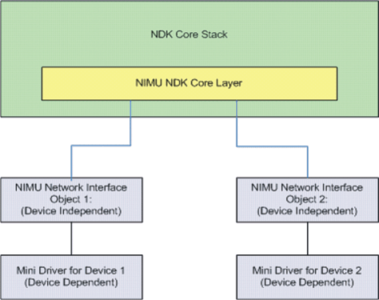

### A.13.2 Data Structure Definition

The NIMU network interface object is equivalent to the device independent packet layer. Each NIMU network interface object is described with the following data structure:

```c
typedef struct NETIF_DEVICE
{
    LIST_NODE links;

    /* Device Identification */
    uint32_t index;
    char name[MAX_INTERFACE_NAME_LEN];

    /* Device Specific Information */
    uint32_t flags;
    uint32_t mtu;
    unsigned char mac_address[6];

    /* Internal Use: Number of references held. */
    uint32_t RefCount;
    uint32_t type;

    /* Pointer to 'driver specific private data' */
    void* pvt_data;

    /*****************************************************************
     ***************** Driver Interface Functions ********************
     *****************************************************************/

    int (*start)(struct NETIF_DEVICE* ptr_net_device);
    int (*stop)(struct NETIF_DEVICE* ptr_net_device);
    void (*poll)(struct NETIF_DEVICE* ptr_net_device, uint32_t timer_tick);
    int (*send)(struct NETIF_DEVICE* ptr_net_device, PBM_Handle hPkt);
    void (*pkt_service) (struct NETIF_DEVICE* ptr_net_device);
    int (*ioctl)(struct NETIF_DEVICE* ptr_net_device, uint32_t cmd,
         void* pbuf, uint32_t size);
    int (*add_header) (struct NETIF_DEVICE* ptr_net_device, PBM_Handle hPkt,
         unsigned char* dst_mac, unsigned char* src_mac, uint16_t ether_type);

} NETIF_DEVICE;
```

The structure entries are described below:

#### links – Pointers to the next and previous devices

**Description** Holds pointers to the previous and next devices in the chain of NIMU registered devices in the system.

#### index – Unique number to identity the device in the system

**Description** Numerically identifies devices uniquely in the system. Driver authors should **not** alter this value. It will be assigned in `NIMURegister()`. The value will be the device’s .init function’s index in the NIMU Device Table + 1.

#### name – Device name

**Description** Name of the device to identify it uniquely in the system. Driver authors can specify a name for the device; but in the case of conflicts its value will be modified to be unique in the system. Therefore, if driver authors are using this in their code it is best to re-read the value after the ‘registration’ process.

#### flags – Device specific flags

**Description** Contains additional information which further describes the network device and its properties. The following flags may be set by a driver author when the NETIF_DEVICE structure is initialized. Flags should not be set at runtime, because the driver modifies flags to maintain information about driver status.

- NIMU_DEVICE_NO_ARP. Device does not support ARP.
- NIMU_DEVICE_NO_FREE. Device is responsible for allocating and freeing the device instance. Setting this flag causes internal calls to *mmFree()* to be omitted. Drivers that set this flag should call *mmFree()* or otherwise free the device instance in the registered stop function. See Section 2.4.2 for details on mmFree(). For example:

```c
    /* Initialization function in driver */
    ptr_device = mmAlloc(sizeof(NETIF_DEVICE));
    mmZeroInit (ptr_device, sizeof(NETIF_DEVICE));
    ...
    ptr_device->flags = NIMU_DEVICE_NO_FREE;
```

- NIMU_DEVICE_ENABLE_HW_CHKSM_TX_ALL. Device configured to compute and insert checksums into outgoing IP, ICMP, TCP and UDP packets in hardware. If this flag is set, software checksum calculations and insertions will be omitted in the respective stack layers, as the hardware is assumed to handle this.
- NIMU_DEVICE_ENABLE_HW_CHKSM_TX_ICMP. Device configured to compute and insert checksums into outgoing ICMP packets in hardware. If this flag is set, ICMP software checksum calculations and insertions will be omitted in the respective stack layers, as the hardware is assumed to handle this.
- NIMU_DEVICE_ENABLE_HW_CHKSM_TX_IP. Device configured to compute and insert checksums into outgoing IP packets in hardware. If this flag is set, IP software checksum calculations and insertions will be omitted in the respective stack layers, as the hardware is assumed to handle this.
- NIMU_DEVICE_ENABLE_HW_CHKSM_TX_UDP. Device configured to compute and insert checksums into outgoing UDP packets in hardware. If this flag is set, UDP software checksum calculations and insertions will be omitted in the respective stack layers, as the hardware is assumed to handle this.
- NIMU_DEVICE_ENABLE_HW_CHKSM_TX_TCP. Device configured to compute and insert checksums into outgoing TCP packets in hardware. If this flag is set, TCP software checksum calculations and insertions will be omitted in the respective stack layers, as the hardware is assumed to handle this.
- NIMU_DEVICE_ENABLE_HW_CHKSM_RX_ALL. Device configured to compute and verify checksums for incoming IP, ICMP, TCP and UDP packets in hardware. If this flag is set, software checksum verifications will be omitted in the respective stack layers, as the hardware is assumed to have handled this.
- NIMU_DEVICE_ENABLE_HW_CHKSM_RX_ICMP. Device configured to compute and verify checksums for incoming ICMP packets in hardware. If this flag is set, ICMP software checksum verifications will be omitted in the respective stack layers, as the hardware is assumed to have handled this.
- NIMU_DEVICE_ENABLE_HW_CHKSM_RX_IP. Device configured to compute and verify checksums for incoming IP packets in hardware. If this flag is set, IP software checksum verifications will be omitted in the respective stack layers, as the hardware is assumed to have handled this.
- NIMU_DEVICE_ENABLE_HW_CHKSM_RX_UDP. Device configured to compute and verify checksums for incoming UDP packets in hardware. If this flag is set, UDP software checksum verifications will be omitted in the respective stack layers, as the hardware is assumed to have handled this.
- NIMU_DEVICE_ENABLE_HW_CHKSM_RX_TCP. Device configured to compute and verify checksums for incoming TCP packets in hardware. If this flag is set, TCP software checksum verifications will be omitted in the respective stack layers, as the hardware is assumed to have handled this.

#### mtu – Maximum transmission unit for the device

**Description** This defines the maximum size of a packet that can be transmitted over the device without any fragmentation. Driver authors should configure this value to the maximum data payload that can be carried without the corresponding Layer2 header. For example, in Ethernet this will be 1514 (maximum data payload) - 14 (L2 Ethernet header) = 1500. By default, the value for mtu is 1500.

#### mac_address – Hardware address of this device

**Description** This is the hardware address of the device that uniquely identifies the device.

#### RefCount – Reference count of the device

**Description** This indicates the number of references of network interface objects held by components. Network Interface objects can only be removed from the system if there are no references of them held in the system. This is used internally by the NIMU control module and should never be modified by the driver.

#### type – Defines the interface type

**Description** For compatibility with the old network interface object, this is set to HTYPE_ETH or HTYPE_PPP depending on the type of network interface object. Moving forward, this field will be obsolete and application authors should use the field instead.

#### pvt_data – Pointer to device-specific private data

**Description** This can be used by the driver authors to store any additional driver-specific data. Memory allocation, Initialization and cleanup is the responsibility of the driver author the NDK NIMU module does not use this field in any way and is opaque to the NDK core stack.

The driver interface functions can be described as follows:

#### start – Callback function registered by driver to open the controller

```c
#include <stkmain.h>

int (*start) (NETIF_DEVICE* ptr_netif_device);
```

**Return Value** The function returns a value of 0 on success and a negative value on error.

**Description** The device start function is a registered call back function which is populated by the device driver author in the network interface object control block. Once the network interface object is registered with the NIMU NDK core stack during the registration process, the NDK core stack will call out this function. Device driver authors are recommended to place hardware initialization and start-up code in this callback function. After the successful completion of the API, the driver should be able to receive and transmit packets from the hardware. Driver authors must specify this callback function or else the NIMU registration will fail.

#### stop – Callback function registered by driver to close the controller

```c
#include <stkmain.h>

int (*stop) (NETIF_DEVICE* ptr_netif_device);
```

**Return Value** The function returns a value of 0 on Success and a negative value on error.

**Description** The device stop function is a registered call back function which is populated by the device driver author in the network interface object control block. The function is invoked by the NDK core stack when the NIMU network interface object is being unregistered from the NIMU system. Driver authors are recommended to place the hardware controller shutdown code in this API. After the successful completion of this API, the driver should not be able to receive or transmit packets. Driver authors must specify this callback function or else the NIMU registration will fail.

#### poll – Callback function registered by driver to be called periodically by the NDK.

```c
#include <stkmain.h>

void (*poll) (NETIF_DEVICE* ptr_netif_device, uint32_t timer_tick);
```

**Return Value** None

**Description** The call back function is used by the NDK core stack to periodically call the driver. Driver authors can use this function to monitor link activity or do any work outside the kernel mode context. The callback function registered here is not called from kernel mode.

The following table summarizes the significance of timer_tick.

| timer_tick | Definition |
| --- | --- |
| 1 | The polling function is called because of a timer event. It is recommended that device authors use this for doing periodic activities such as link management, watchdog timers, etc. |
| 0 | This indicates that the polling function has been called because the driver has indicated a `STKEVENT_signal`. This is useful for device authors to signify some activity outside kernel mode. |

#### send – Callback function registered by driver to send packets.

```c
#include <stkmain.h>

int (*send) (NETIF_DEVICE* ptr_netif_device,
             PBM_Handle    hPkt );
```

**Return Value** The function returns a value of 0 on success and a negative value on error. On success, the packet memory cleanup needs to be handled by the driver; but if an error is returned, the NDK core stack will clean up the packet.

**Description** The device send function is an API which is used by the core NDK stack to pass packets to the driver for transmission. Driver authors must specify this callback function or else the NIMU registration will fail.

#### pkt_service – Callback function registered by driver for the NDK stack to receive packets

```c
#include <stkmain.h>

void (*pkt_service) (NETIF_DEVICE* ptr_netif_device);
```

**Return Value** None

**Description** The API is used by the NDK core stack to receive packets from the driver. This is indicated through the STKEVENT_signal API once the packets have been received. The NDK core scheduler detects this signal and ensures that the appropriate packet service API is called. This function is called from kernel mode. The drivers should handle conditions where even though this API is called there are no packets in the receive queue.

#### ioctl – Callback function registered by driver for the NDK stack to get/set configuration

```c
#include <stkmain.h>

void (*ioctl) (NETIF_DEVICE  *ptr_device,
               uint32_t      cmd,
               void          *pBuf,
               uint32_t size );
```

**Return Value** The function returns a value of 0 on Success and a negative value on error.

**Description** This API is used by the NDK core stack to be able to get/set configuration in the drivers. The interface can be used to configure the multicast address list, change device MAC address, etc. Each NIMU network interface object can also identify its own custom IOCTL commands to do any device-specific configuration. This function is called from kernel mode.

#### add_header – Callback function registered by driver for the NDK stack to add custom L2 header

```c
#include <stkmain.h>

void (*add_header)(NETIF_DEVICE*  ptr_netif_device,
                   PBM_Handle     hPkt,
                   unsigned char* dst_mac,
                   unsigned char* src_mac,
                   uint16_t       ether_type);
```

**Return Value** None

**Description** This is a registered call back function added by the driver to add custom layer2 headers on packets. This is called by the NDK core stack after layer3 has done its work. Ethernet driver authors can set this API to be NIMUAddEthernetHeader. However, if the driver is not a standard Ethernet driver, this can be used to add an appropriate layer2 header. For example, If the driver is USB-RNDIS, then this function can be defined to add not only the standard Ethernet header, but also the RNDIS header. If there are custom headers, then ensure there is sufficient head room in the packet buffers which are being allocated. Configuration of header and trailer sizes are provided by the NIMU exported API NIMUSetRsvdSizeInfo. This function is called from kernel mode.

### A.13.3 NIMU Configuration

For sample NIMU API usage, please refer to the DSK6455 and DM642 Ethernet driver code in the latest platform specific packages.

### A.13.4 API Function Overview

| Function | Description |
| --- | --- |
| NIMURegister | Registers a NIMU compliant network interface object |
| NIMUUnregister | Un-registers a NIMU compliant network interface object |
| NIMUGetRsvdSizeInfo | Get current header and trailer size |
| NIMUSetRsvdSizeInfo | Set current header and trailer size |
| NIMUReceivePacket | Interface API to pass packets to the NDK core stack |
| NIMUIoctl | Get/set configuration from the NIMU module and drivers |

### A.13.5 API Function Description

#### NIMURegister – Callback Registers a NIMU compliant network interface object

```c
#include <stkmain.h>

int NIMURegister (NETIF_DEVICE* ptr_netif_device);
```

**Return Value** The function returns a value of 0 on success and a negative value on error.

**Description** The API is used to register a NIMU compliant network interface object with the core NDK NIMU module. As part of the registration process, the API will also invoke the *start* API to open and begin the corresponding the network device.

#### NIMUUnregister – Un-registers a NIMU compliant network interface object

```c
#include <stkmain.h>

int NIMUUnregister (NETIF_DEVICE* ptr_netif_device);
```

**Return Value** The function returns a value of 0 on success and a negative value on error.

**Description** The API is used to un-register a previously registered NIMU compliant network interface object from the core NDK NIMU module. As part of the un-registration process, the API will also invoke the *stop* API to close the corresponding network device. This API can only be called from within kernel mode.

#### NIMUGetRsvdSizeInfo – Get current header and trailer size

```c
_include <stkmain.h>_

_void NIMUGetRsvdSizeInfo ( int *hdr_size,
                            Int *trail_size );_
```

**Return Value** The function returns the current header and trailer reserved space.

**Description** All packets set aside by the network interface management unit are allocated reserving some space for headers and trailers. The API is used to get the current header and trailer size that NIMU will use from this point on. This API can only be called from within kernel mode.

#### NIMUSetRsvdSizeInfo – Set current header and trailer size

```c
#include <stkmain.h>

void NIMUSetRsvdSizeInfo (int hdr_size,
                          int trail_size);
```

**Return Value** None

**Description** All packets set aside by the network interface management unit are allocated reserving some space for headers and trailers. The API is used to set the current header and trailer size that NIMU will use from this point on. There are no validations done on the header and trailer size values passed to the function. It is assumed that the system authors have configured this value correctly. This API can only be called from within kernel mode.

#### NIMUReceivePacket – Interface API to pass packets to the NDK Core stack

```c
#include <stkmain.h>

int NIMUReceivePacket (PBM_Handle hPkt);
```

**Return Value** The function returns the 0 on success and <0 on error. Note that in case of error, the function will clean the packet memory.

**Description** This is the interface function which has been exported by the NIMU module to pass received packets to the networking stack. This API is available only for NIMU network interface objects and replaces the EtherRxPacket API, which handles the LL packet architecture. This API can only be called from within kernel mode.

#### NIMUIoctl – Get/Set configuration from the NIMU Module and Drivers

```c
#include <stkmain.h>

int NIMUIoctl( uint32_t cmd,
               NIMU_IF_REQ *ptr_nimu_ifreq,
               Void *pBuf,
               uint32_t size );
```

**Return Value** The function returns the 0 on success and a negative value on error.

**Description** This function is used to get and set configuration parameters from either the NIMU module or to the NIMU network interface objects driver attached to the NIMU module. The NIMU_IF_REQ structure is defined as follows:

```c
typedef struct NIMU_IF_REQ
{
    uint32_t index;                        /* Device Index */
    char     name[MAX_INTERFACE_NAME_LEN]; /* Device Name */
} NIMU_IF_REQ;
```

The structure is used to identify the NIMU network interface object which is being referred to. The introduction of NIMU network interface objects can be referred by a *name* or by a *unique index*. The NIMU IOCTL Interface searches for a matching device using the *name*; if no device is found then the device index is used to find a matching device. If none is found then an error is returned. The cmd parameter is used to specify the command, and *pBuf* and *size* are defined on a per command basis. The following table summarizes the set of supported IOCTL commands and the values expected in the pBuf and size.

[output not shown]

Typically, most of the requests are done for a specific network interface object; but in some cases, configuration might be required for all NIMU network interface objects. In the case of these special cmd, the value of the interface request is NULL. These special case cmd are shown in the following table.

[output not shown]

This API cannot be called from kernel mode. It is recommended that system application authors use this API instead of directly trying to access low layer information.

## A.14 Virtual LAN (VLAN) Support

### A.14.1 Synopsis

Virtual LAN (VLAN) support in NDK adds the capability of receiving and transmitting VLAN tagged packets through the stack. VLAN support in NDK is available only in conjunction with NIMU architecture.

Figure A-2 highlights the VLAN module components in reference to the NIMU enabled NDK stack.

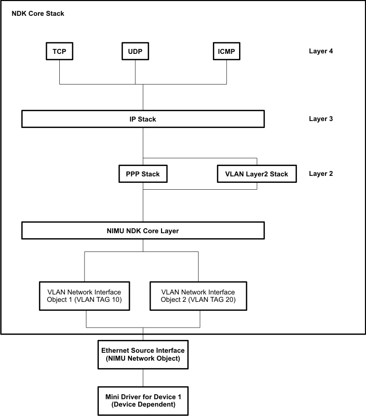

The NIMU core and VLAN modules in the NDK stack are closely tied together. The VLAN module is brought down by the NIMU as a part of its de-initializing routine during the system shutdown. Similarly, the NIMU module’s packet receive routine is responsible for handing over all VLAN tagged packets to the VLAN module for processing. It does so by checking all incoming packets for their L2 type and if it is VLAN, forwards the packets onto the VLAN module of the stack for further processing.

VLAN implementation has 2 parts:

- VLAN Layer2 stack that is responsible for the addition and deletion of VLAN headers in the transmit and receive paths.
- VLAN network interface objects which are instances of NIMU devices with VLAN specific attributes like a VLAN Identifier, user priority, etc.

A VLAN network interface object is a NIMU device characterized additionally by these VLAN specific attributes:

- VLAN Identifier - Each VLAN node is identified by a unique VLAN identifier per source interface.
- Source Interface - The VLAN source interface is the actual physical interface on which the VLAN nodes are executing. This is the actual physical Ethernet interface on which packets are received and transmitted.
- Default Priority - VLAN tagged packets carry a 16-bit tag also known as the tag control information (TCI) header. This field internally carries a 3-bit user priority. The value here is the *default priority* which is filled in these fields if the packet to be transmitted has no *priority specified*.
- User Priority Mapping - The user priority mappings are specified to remap the packet priority to a 3-bit user priority.

### A.14.2 User Priority Mapping Configuration

A user application can configure the user priority for a VLAN device using the *NDK_setsockopt()* API, which is discussed in great detail in Section 3.3.3. The following sections provide an example on how the VLAN user priority can be communicated by an application to the VLAN module in the core stack and how they are translated to bits in VLAN header of the packets.

### A.14.2.1 User Priority Configuration

Figure A-3 shows two applications that use the NDK stack to communicate with other devices on the network through an Ethernet interface. The applications use the socket APIs described in Section 3.3.3 to send/receive packets through the device. With VLAN support, there should be a mechanism which the application authors will use to communicate the VLAN user priority value to associate their socket to the stack. This enables the stack to mark the user priority bits appropriately in the VLAN headers of the packets.

In Figure A-3, let’s assume that Application1 is a high priority application and Application2 is a lower priority application. The network administrators on which the Ethernet is physically connected should have defined a *Traffic Conditioning Agreement*. All devices connected on that network should comply to this agreement that defines the user priority values for high and low priority application.

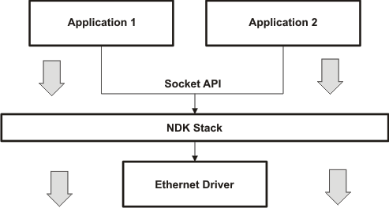

Assuming that the traffic condition agreement mentioned in Section A.14.2.1 is as follows:

| Application Priority | VLAN User Priority Bits |
| --- | --- |
| High | 7 |
| Low | 5 |
| Undefined | 0 |

This implies that all packets generated by Application1 should be marked with the user priority value of 7. Similarly, all packets generated by Application2 should be marked with the user priority value of 5.

Each application is capable of sending and receiving packets only through the socket interface; therefore, you need to ensure that all sockets that send packets in Application1 are mapped to the correct priority level to ensure that they are marked to the user priority value of 7.

The other advantage of working out priority at the socket level instead of the application level is that *granularity* exists which allows prioritization even inside the applications. For example, one data flow in Application1 could be low priority while the other could be high priority.

As mentioned before, the user priority can be communicated by the application using *NDK_setsockopt* API with the socket option parameter set to *SO_PRIORITY* and the value set to the appropriate user priority. Note that the valid range for the user priority is 0 - 7; although a value of 0xFFFF can be used to reset the priority back to default. For more details on how to get/set the user priority using getsockopt() and setsockopt() socket APIs, see Section 3.3.3.

Example

The following example configures the socket priority to be 0:

```c
uint16_t priority = 0;
if (NDK_setsockopt(s, SOL_SOCKET, SO_PRIORITY, &priority, sizeof(priority) < 0)
    printf ("TEST Case Failed: 0x%x\n", fdError());
```

> **NOTE:** Configuration of the socket priority is equivalent of indicating what the priority of the application is. The socket priority has no meaning outside the stack and is only used internally.

### A.14.2.2 Marking Packet Priority

This section documents how the translation needs to be done to mark the *user priority bits*. Once an application has marked the socket priority, the VLAN module translates the socket priority to user priority bits using the following formula:

`prio_mapping[socket_priority] = VLAN User Priority`

The table in the previous section shows the traffic conditioning agreement for the VLAN user priority bits. It indicates that Application1 has HIGH priority so the VLAN module should mark its VLAN user priority bits set to 7 and that Application2 has LOW priority so the VLAN module should mark its VLAN user priority bits set to 5.

To satisfy this requirement, Application1 should have the following code snippet:

```c
uint16_t priority = 0;
if (NDK_setsockopt(s, SOL_SOCKET, SO_PRIORITY, &priority, sizeof(priority) < 0)
    printf ("TEST Case Failed: 0x%x\n", fdError());
```

The idea is that all packets generated by Application1 will have a socket priority of 0 (HIGH).

Similarly, Application2 should have the following code snippet:

```c
uint16_t priority = 1;
if (NDK_setsockopt(s, SOL_SOCKET, SO_PRIORITY, &priority, sizeof(priority) < 0)
    printf ("TEST Case Failed: 0x%x\n", fdError());
```

The idea is that all packets generated by Application2 will have a socket priority of 1 (LOW).

The VLAN device should be created with the following code snippet:

```c
/* By default: We configure the priority mapping to be as follows:-
 * Priority | VLAN User Priority
 * -----------------------------------
 *    0     |     7
 *    1     |     5
 *    2     |     0
 *    3     |     0
 *    4     |     0
 *    5     |     0
 *    6     |     0
 *    7     |     0
 */
prio_mapping[0] = 7;
prio_mapping[1] = 5;
prio_mapping[2] = 0;
prio_mapping[3] = 0;
prio_mapping[4] = 0;
prio_mapping[5] = 0;
prio_mapping[6] = 0;
prio_mapping[7] = 0;

/* Use the VLAN API to create a new VLAN device. */
if (VLANAddDevice (src_index, 10, 0, prio_mapping) < 0)
    printf ("Error VLAN Failed errcode=%d\n");
```

The important point to note in this example is the configuration of the user priority table. This is basically the translation of the traffic conditioning agreement to an array.

With the VLAN device created as follows, if a packet is transmitted from Application1 it is marked with a socket priority of 0, and then it is translated by the VLAN module to user priority 7.

### A.14.3 Configuring VLAN To Send Data To A Linux PC

This section provides an overview of how to set up a VLAN device using the available commands in the NDK Telnet console. The commands are used to create and configure a VLAN device, and then send data over that device to a Linux PC. Note that the steps in this section assume Ubuntu Linux; however, similar commands should be available on other versions of Linux.

### A.14.3.1 Configuring VLAN On the Linux PC

1. Ensure your Linux box has the `vlan` application. If not, it can be installed by running the following command:

   ```
   sudo apt-get install vlan
   ```

2. The `ncat` or a similar application is also needed. It can be installed by running the following command:

   ```
   sudo apt-get install ncat
   ```

3. The Wireshark application is recommended, but not required. It can be installed by running the following command:

   ```
   sudo apt-get install wireshark
   ```

4. Load the 8021q module into the kernel:

   ```
   sudo modprobe 8021q
   ```

5. Assuming you’re connected on interface `eth0` (with IP address 192.168.0.31):

   ```
   ifconfig
   eth0  Link encap:Ethernet  HWaddr --:--:--:--:--:--
         inet addr:192.168.0.31  Bcast:192.168.0.255  Mask:255.255.255.0
         UP BROADCAST RUNNING MULTICAST  MTU:1500  Metric:1
         RX packets:446 errors:0 dropped:0 overruns:0 frame:0
         TX packets:0 errors:0 dropped:0 overruns:0 carrier:0
         collisions:0 txqueuelen:1000
         RX bytes:38520 (38.5 KB)  TX bytes:33324 (33.3 KB)
   ```

6. Use the vconfig command to add a new VLAN interface with VLAN ID 10. This will create a new interface, but it will not have any IP address assigned to it:

   ```
   sudo vconfig add eth0 10
   ```

7. Assign an IP address to the VLAN interface, choosing a different network:

   ```
   sudo ip addr add 10.90.90.15/24 broadcast 10.90.90.255 dev eth0.10
   ```

8. Ensure that the interface is up:

   ```
   sudo ip link set up eth0.10
   ```

9. You should now see the following detailed in the ifconfig command for the VLAN interface:

   ```
   eth0.10   Link encap:Ethernet  HWaddr --:--:--:--:--:--
         inet addr:10.90.90.15  Bcast:10.90.90.255  Mask:255.255.255.0
         UP BROADCAST RUNNING MULTICAST  MTU:1500  Metric:1
         RX packets:21 errors:0 dropped:0 overruns:0 frame:0
         TX packets:26 errors:0 dropped:0 overruns:0 carrier:0
         collisions:0 txqueuelen:0
         RX bytes:5951 (5.9 KB)  TX bytes:6643 (6.6 KB)
   ```

10. Use `ncat` to run a UDP echo server on port 10000, in order to receive incoming VLAN packets sent from the NDK:

    ```
    ncat -e /bin/cat -k -u -l 10000
    ```

11. Run Wireshark on the VLAN interface `eth0.10` to capture packets sent to the VLAN interface
12. The Linux side is now ready to receive VLAN UDP packets

### A.14.3.2 Configuring VLAN In The NDK

The following steps provide an overview of how to add and configure a VLAN device, using the commands available in the Telnet console.

1. Build an NDK application that enables the Telnet console. The app should be DHCP enabled to get an IP automatically.
2. Load and run the application.
3. From a terminal, telnet into the NDK application using the IP address obtained from DHCP.
4. Run the `ipaddr` command to display the list of interfaces and associated IP addresses configured for the NDK:

   ```
   >ipaddr all
   Interface Name: eth0
   Interface Id  : 1
   IP Address    : 192.168.0.9
   IP Mask       : 255.255.255.0
   MTU           : 1500 bytes
   MAC Address   : --:--:--:--:--:--
   ```

5. Use the `vlan` command to add a new VLAN interface on top of the existing Ethernet interface (IF number 1). Use VLAN ID 10 and priority of 4:

   ```
   >vlan add 1 10 4
   Successfully created new VLAN Device 2
   ```

6. Repeat the `ipaddr` command. You should now see the new VLAN interface, in addition to the previously seen Ethernet interface:

   ```
   >ipaddr all
   Interface Name: eth0:10
   Interface Id  : 2
   MTU           : 1496 bytes
   MAC Address   : --:--:--:--:--:--
   Interface Name: eth0
   Interface Id  : 1
   IP Address    : 192.168.0.9
   IP Mask       : 255.255.255.0
   MTU           : 1500 bytes
   MAC Address   : --:--:--:--:--:--
   ```

7. Use the `ipaddr` command to assign an IP address to the VLAN interface:

   ```
   >ipaddr 2 10.90.90.21 255.255.255.0
   ```

8. Again, repeat the `ipaddr` command. You will see the VLAN interface now has the IP associated with it:

   ```
   >ipaddr all
   Interface Name: eth0:10
   Interface Id  : 2
   IP Address    : 10.90.90.21
   IP Mask       : 255.255.255.0
   MTU           : 1496 bytes
   MAC Address   : --:--:--:--:--:--
   ```

### A.14.3.3 Sending Data Over The VLAN Device

9. Run the `vlan send` command to send UDP packets to the Linux laptop on port 10000:

   ```
   >vlan send 10.90.90.15
   TEST Case Passed: Priority 0x8 is incorrect and was detected
   Packet with priority 0 has been sent
   Packet with priority 1 has been sent
   Packet with priority 2 has been sent
   Packet with priority 3 has been sent
   Packet with priority 4 has been sent
   Packet with priority 5 has been sent
   Packet with priority 6 has been sent
   Packet with priority 7 has been sent
   Packet with default priority has been sent
   ```

10. On the Linux PC, you should see the packets being sent in Wireshark. If you inspect the Ethernet frame, you will see the VLAN header and ID of 10

### A.14.4 VLAN API Functions

This section details the VLAN APIs. Note, some functions are for internal stack usage only.

### A.14.4.1 Function Overview

The following are the APIs exported by the VLAN module in the core stack.

| Function | Description |
| --- | --- |
| VLANInit | Initializes the VLAN module in the core NDK stack. |
| VLANDeinit | Deinitalizes the VLAN module and shuts down all the VLAN enabled NIMU network interface objects in the system. |
| VLANReceivePacket | Handles all VLAN tagged packets on the receive path. |
| VLANAddDevice | Creates a VLAN device on a specified NIMU interface. |
| VLANDelDevice | Deletes a previously created VLAN device. |

### A.14.4.2 API Functions

#### VLANInit – Initializes the VLAN module in the core NDK stack.

```c
#include <stkmain.h>

void VLANInit (void)
```

**Return Value** None

**Description** This function is used to initialize the VLAN module in the NDK core stack. It is for internal stack usage only and should not be called by any application directly. This function is called as a part of the stack bring up, i.e., NC_NetStart invocation by the user application. It initializes the header and trailer sizes for VLAN NIMU objects that would be created in the system later by a user application.

#### VLANDeinit – Deinitalizes VLAN module and shuts down VLAN enabled NIMU network interface objects

```c
#include <stkmain.h>

void VLANDeinit (void);
```

**Return Value** None

**Description** This function is used to shut down the VLAN module in the core stack. It closes and shuts down any VLAN enabled NIMU network interface objects existent in the system. This function is for internal stack usage only and should not be called by any application directly. It is called as a part of stack teardown, i.e., when the user application invokes NC_NetStop function.

#### VLANReceivePacket – Handles all VLAN tagged packets on the receive path

```c
#include <stkmain.h>

uint32_t VLANReceivePacket (PBM_Handle hPkt);
```

**Return Value** Returns 0xFFFF on error and on success returns the values of the encapsulated protocol.

**Description** This function is called by the NIMU receive function when a VLAN tagged packet is received. It validates the packet and ensures that there is a valid VLAN node on the system that can process the packet. This function is for internal stack usage only and should not be called by any application directly.

#### VLANAddDevice – Create a VLAN Network Interface object

```c
#include <stkmain.h>

int VLANAddDevice (uint32_t      src_index,
                   uint16_t      vlan_id,
                   unsigned char default_priority,
                   unsigned char prio_mapping[]);
```

**Return Value** This function returns the device index of the new VLAN network interface object created on a success or a negative value on error.

**Description** This API enables system developers to create a VLAN Network Interface object on a specified NIMU source interface based on the arguments supplied. Note that this function must be called from user mode only.

#### VLANDelDevice – Deletes a previously created VLAN device

```c
#include <stkmain.h>

int VLANDelDevice (uint16_t dev_index);
```

**Return Value** This function returns 0 on a success or a negative value on error.

**Description** This API deletes a previously created VLAN network interface object. The device index passed is the index returned from the prior invocation of the VLANAddDevice API. Note that this function must be called from user mode only.

## A.15 Raw Ethernet Module

### A.15.1 Synopsis

A new module called the *Raw Ethernet Module* has been added to the NIMU enabled NDK stack to handle the Raw Ethernet packet traffic through NDK. A Raw Ethernet packet can be defined as an Ethernet packet whose Protocol type (Offset 12 in the Ethernet header) doesn’t match any of the well-known standard protocol types like IP (0x800), IPv6 (0x86DD), VLAN (0x8100), PPPoE Control (0x8863), PPPoE Data (0x8864). The Raw Ethernet Module interfaces with the application and the stack to provide the APIs required in configuring a raw Ethernet socket, and in sending and receiving packets using it.

Figure A-4 shows the placement of the Raw Ethernet module in the NDK stack.

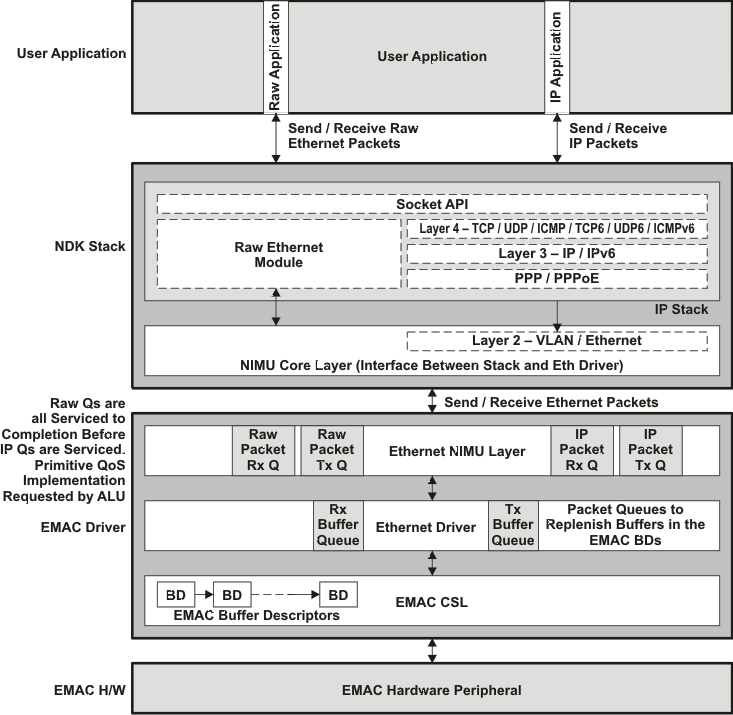

As Figure A-4 illustrates, traditional data path for the IP packets is different from the data path followed by the Raw Ethernet packets. The complete Layer 4, Layer 3 and Layer 2 processing in the NDK IP stack is bypassed for the Raw Ethernet packets. The Raw Ethernet packets alternatively travel through the Raw Ethernet Module which maintains a mapping between the custom Ethernet type configured and the interface on which the packets should be transmitted. This mapping is maintained in the “Raw Ethernet Socket” object structure. Also, shown in the above figure is the implementation of Raw Ethernet prioritization implementation in the driver using separate queues for IP and raw Ethernet traffic. This implementation is just an illustration of how this feature can be extended further to suit any application demands and is not really tied in with the design of Raw Ethernet Socket and Modules.

> **NOTE:** The Raw Ethernet Module is supported only with NIMU enabled NDK stacks and drivers.

For more details on the Raw Ethernet Socket APIs, see Section 3.4 of this document.

### A.15.2 Raw Ethernet Data Prioritization - Socket Priority Use Case

A user application can use the Socket Priority to add any sort of special differentiation that the raw Ethernet application would require for all packets travelling using the specified socket. For example, if there exists two raw Ethernet sockets, they could be both configured with different priorities using *NDK_setsockopt()* API discussed in Section 3.3.3. Further, a desired QoS scheme can be implemented in the Ethernet driver using this priority that is carried onto the packets. It can be also used by an application to map the priority to certain transmission properties like EMAC channel number on which the packets are to be transmitted etc. This section describes one such implementation of Socket Priority to implement Raw Ethernet Packet Prioritization over traditional IP traffic.

### A.15.2.1 Socket Priority Configuration

In this specific use case, the application requires that:

- Raw Ethernet traffic and traditional IP traffic to be sent out on two separate EMAC channels.
- Further, it also requires that both on Transmit (Tx) and Receive (Rx) paths, the Raw Ethernet data is always serviced before the IP data.

For the implementation to achieve this also has two requirements:

- For requirement 1, the application would have to create a Raw Ethernet socket and configure the socket priority to carry the EMAC channel number. The Raw Ethernet module in turn will ensure that all packets travelling using this socket are tagged with the EMAC channel number in their “PktPriority” field. The socket priority configuration is shown in the following example:

The following example creates a Raw Ethernet socket and configures the EMAC channel number to 3 using socket priority:

```c
SOCKET sraw = INVALID_SOCKET;
uint16_t priority = 0;
int retVal, val;

/* Allocate the file environment for this task */
fdOpenSession( TaskSelf() );

/* Create the raw Ethernet socket */
sraw = NDK_socket(AF_RAWETH, SOCK_RAWETH, 0x300);
if( sraw == INVALID_SOCKET )
{
    printf("Fail socket, %d\n", fdError());
    fdCloseSession (TaskSelf());
    return;
}

/* Configure the transmit device */
val = 1;
retVal = NDK_setsockopt(sraw, SOL_SOCKET, SO_IFDEVICE, &val, sizeof(val));
if(retVal)
    printf("error in setsockopt \n");

/* Configure the EMAC channel number */
val = 3;
retVal = NDK_setsockopt(sraw, SOL_SOCKET, SO_PRIORITY, &val, sizeof(val));
if(retVal)
    printf("error in setsockopt \n");
```

- Secondly, to implement the prioritization and also obtain the EMAC channel number on which the packet needs to be transmitted, the EMAC driver can inspect the “PktPriority” field of the packet and use it to enqueue the packet to the hardware accordingly. A code snippet from the Ethernet driver is shown below for illustration purposes:

  This is a code snippet from the “Send” routine of the Ethernet driver.

```c
/* Peek into the packet to check out if any prioritization is needed.
 *
 * All raw Ethernet packets are tagged with the EMAC channel number onto
 * which they need to be sent out in the PktPriority field.
 */
if (((PBM_Pkt *)hPkt)->PktPriority != PRIORITY_UNDEFINED)
{
    /* Enqueue the packet in the Raw Tx Queue and send it for transmission.
     * Use the PktPriority field now as the EMAC channel number on which
     * packet needs to be Txed
     */
}
else
{
    /* This is just a normal IP packet. Enqueue the packet in the
     * Tx queue and send it for transmission.
     */
}
```

For more details on this use case implementation, please refer to the Ethernet driver code packaged in the NSP for TCI6488.

### A.15.3 API Function Overview

The following APIs are exported by the Raw Ethernet module of the core NDK stack:

| Function | Description |
| --- | --- |
| RawEthTxPacket | API to send out Raw Ethernet data using Raw Ethernet sockets |
| RawEthTxPacketNC | API to send out Raw Ethernet data using Raw Ethernet sockets without any copy |
| RawEthRxPacket | API to handle raw Ethernet packets received by the stack |

### A.15.4 API Functions

#### RawEthTxPacket – Sends out Raw Ethernet data, creates a copy of the data.

```c
int RawEthTxPacket (void* hRawEthSock,
                    char* pBuffer,
                    int   len);
```

**Parameters**

- hRawEthSock: Handle to the raw Ethernet socket
- pBuffer: Handle to the data buffer that needs to be sent
- len: Length of data contained in the data buffer pBuffer.

**Return Value**

- 0: Successfully sent out the packet
- ENOBUFS: Error allocating memory for the packet. Packet not sent out.

**Description** This is the API called by the Raw Ethernet sockets module to transmit data sent by the application. This API allocates memory for the packet and the buffer according to the length specified, copies over the contents of the application buffer to the packet, and finally populates any socket priority configured on the socket to the *PktPriority* field of the packet for further use by the stack or the driver. It also increments the Raw Ethernet success stats if the transmit succeeded. This API invokes the NIMUSendPacket API to send out the packet eventually.

#### RawEthTxPacketNC – Sends out Raw Ethernet data, without any copy of the data.

```c
int RawEthTxPacketNC (void *hRawEthSock,
                      char* pBuffer,
                      int len,
                      void *hPkt);
```

**Parameters**

- hRawEthSock: Handle to the raw Ethernet socket
- pBuffer: Handle to the data buffer that needs to be sent
- len: Length of data contained in the data buffer pBuffer
- hPkt: Handle to the packet that needs to be sent. The pBuffer is the data buffer

**Return Value**

- 0: Successfully sent out the packet
- EINVAL: Bad Packet / Buffer Handles. Packet not sent out

**Description** This is the API called by the Raw Ethernet sockets module to transmit data sent by the application without making any copy of it on the Tx path. This API is very useful for applications which have very definite performance requirements for their application. The buffers and packet handles passed here can be obtained in advance using the socket API *getsendncbuff()* by the application , then can be used to fill data and finally invoke the *sendnc()* API to transmit this data. The send no-copy API of the raw Ethernet socket module in turn invokes this API for finally transmitting the data. The raw Ethernet socket APIs are all discussed in detail in Section 3.4 of this document. This API validates the packet and buffer handles, and populates any socket priority configured on the socket to the *PktPriority* field of the packet for further use by the stack or the driver. It finally invokes the *NIMUSendPacket* API to send out the packet eventually. It also increments the Raw Ethernet success stats if the transmit succeeded. No memory allocations or copies are made by this API and hence is less intensive in terms of performance.

#### RawEthRxPacket – Receive handler for Raw Ethernet traffic in the stack.

```c
int RawEthRxPacket (PBM_Handle hPkt);
```

**Parameters**

- hPkt: Handle to the packet which is passed up to the stack by the Ethernet

**Return Value**

- 0: Success
- 1: Error

**Description** This API is called by the NIMU layer when the Ethernet if a raw Ethernet socket object exists for the Ethernet type in the packet and if so enqueues in the socket buffer for the application to receive. No copies are made of the packet and the buffers further on the receive path by the Raw Ethernet socket layer and the packet is as is handed over for the application to use. This API also increments the Raw Ethernet receive stats accordingly.

## A.16 Obtaining Stack Statistics

Stack statistics are available from global structures or global arrays exported by the stack library. The declaration of these global identifiers appears in the interface specification for the individual protocols. The following protocols contain statistics information:

| Protocol | Statistics Definition |
| --- | --- |
| IP | IPIF.H |
| ICMP | ICMPIF.H |
| TCP | TCPIF.H |
| UDP | UDPIF.H |
| Raw Transport (non-TCP/UDP) | RAWIF.H |
| Network Address Translation | NATIF.H |
| Raw Ethernet | AWETHIF.H |

# B Network Address Translation

This section is required only for system programming that needs low level access to the Network Address Translation (NAT) layer. **This API does not apply to sockets application programming.**

This section describes functions that are callable from the kernel layer. You should be familiar with the operation of the operation of *llEnter()*/*llExit()* functions before attempting to use the APIs described in this section (see Section A.1.2).

NAT has a unique status in the stack software because it can be an integral part of programming at both the user and kernel levels, or can be entirely redundant and even purged from the stack build.

This section describes the operation of the Network Address Translation software included in the NDK, how to configure it, how to install port mappings, and how to program proxy filter routines to support protocols like FTP.

## B.1 NAT Operation

NAT is a translation of packet IP address. It is used by the stack when routing, to translate the IP address of a packet to/from a private LAN from/to a public WAN. NAT is required when the IP address paradigms on either side of the router are incompatible; for example, virtual addresses vs. physical addresses, or private vs. public. In the case of a home LAN, NAT allows multiple clients on the home LAN to use a single ISP account by sharing the router WAN IP address obtained from the ISP.

### B.1.1 Typical Configuration

For the examples that follow, consider the typical configuration illustrated in Figure B-1. The NDK is executing as a home router (HR) and connects the home LAN subnet (192.168.0.x) to the Internet (WAN) via an ISP that has assigned HR an address of 128.1.2.12. The hosts on the home network (H1 and H2) have obtained their internet addresses from HR via DHCP. The IP of HR on the home LAN as well as the IP subnet used by the home LAN is pre-configured in HR. Figure B-1 also shows a host on the public internet (IH) to which the LAN hosts will connect. Lastly, it is assumed that the home LAN subnet is virtual, and NAT is required to allow H1 and H2 to share the WAN IP address assigned to HR by the ISP (128.1.2.12).

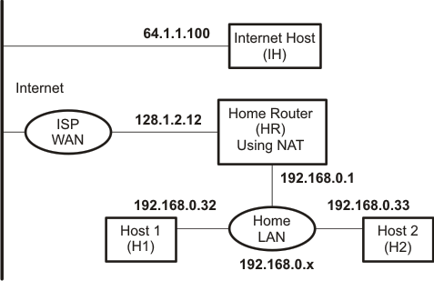

### B.1.2 Basic NAT

When sharing a single WAN IP address, the IP address obtained from the ISP is assigned to the router (the NDK in routing mode). Client machines that are to share the IP address are placed on the home LAN. The router routes traffic between the LAN and the WAN (internet via the ISP).

As packets traverse from the LAN to the WAN across the router, the source IP address of the packet (a LAN address) is replaced with the public IP address of the router. The result is that all packets sent to the WAN appear to have originated from the router with the public IP address obtained from the ISP.

As packets traverse from the WAN to the LAN across the router, the destination IP address of the packet (the router’s WAN IP as obtained from the ISP) is replaced with the home LAN IP address of the physical client machine to which the packet is ultimately destined.

To perform this translation successfully, some details must be addressed. First, to allow multiple clients to share the public IP address in a non-ambiguous fashion, there must exist a deterministic method of mapping packets from the WAN to their correct destination on the LAN. This is done by keeping records of LAN IP clients that have initiated IP traffic, and by altering the TCP/UDP port (or ICMP Id field) as well as the IP address when performing the translation.

Every time a LAN client sends a packet to the WAN, the local IP address, port/id, and protocol is recorded for reverse mapping, as well as the destination IP address and port for security. When a packet is received from the WAN, the destination port/id is checked against the current database of NAT entries to see if the packet’s destination address and port/id should be translated to a LAN client.

For example, when accessing the Internet, all communication is normally initiated by the client. In this case, communication will be initiated by H1 or H2. Assume that H1 attempts to establish an HTTP connection with the Internet host (IH). It will send a connection request to the IP address assigned to IH, and a TCP port value of 80, which is HTTP. The request will be from its own IP address with an ephemeral port value that is picked from a pool (consider it random for these purposes- for example, 1001). So the request will be addressed as follows:

**Packet 1**

| To | From | Protocol |
| --- | --- | --- |
| 64.1.1.100 : 80 | 192.168.0.32 : 1001 | TCP |

When the router HR receives this packet, it searches for a NAT entry that matches the *From* address of the packet. Because this is the first packet, assume the table is empty. When no entry is found, (skipping proxies for now) the router will create a new entry. It does this by recording information from packet 1, as well as picking a new port value from its own pool that has been specifically reserved for NAT (assume the range is 50000 to 55000, and that it chooses 50001). The new port is used as the packet’s source port. The NAT entry record would look like the following:

**NAT Entry Table**

| Foreign IP | Foreign Port | Local IP | Local Port | Mapped Port | IP Protocol | TCP State | Timeout |
| --- | --- | --- | --- | --- | --- | --- | --- |
| 64.1.1.100 | 80 | 192.168.0.32 | 1001 | 50001 | TCP | SYNSENT | 00:01:00 |

The *Local IP* and *Local Port* values are those that are local to hosts on the home LAN. The *Foreign IP* value is the foreign side of the connection as viewed by hosts on the home LAN. The *Mapped Port* value is the source port when the packet is sent from HR. The source IP address used in the packet is that assigned to HR by the ISP. The IP protocol of the packet is recorded, and when using TCP, the state of the TCP connection is tracked to establish a reasonable timeout value. The SYNSENT value indicates that a connection request was sent. Before a full connection is established, the timeout is set fairly low - for example, 1 minute.

As the packet is transmitted from HR to the ISP, it would look like the following:

**Packet 1 (modified)**

| To | From | Protocol |
| --- | --- | --- |
| 64.1.1.100 : 80 | 128.1.2.12 : 50001 | TCP |

When IH receives the packet, it believes that the connection request came from HR. It thus sends the response packet to HR. The packet would be addressed as follows:

**Packet 2 (response to packet 1)**

| To | From | Protocol |
| --- | --- | --- |
| 128.1.2.12 : 50001 | 64.1.1.100 : 80 | TCP |

When HR receives the packet, it checks the NAT entry table for an entry with a *Mapped Port* value equal to the destination port of the packet (in this case 50001). The value of *Protocol* and the source IP address/port values must also match the *Protocol*, *Foreign IP*, and *Foreign Port* fields of the NAT entry. This helps ensure that the reply is from the desired server.

Here, HR finds the entry and proceeds to modify the packet. It replaces the destination address/port with the local address/port stored in the entry. It also resets the timeout of the entry. After modification, the packet would be addressed as follows:

**Packet 2 (modified)**

| To | From | Protocol |
| --- | --- | --- |
| 192.168.0.32 : 1001 | 64.1.1.100 : 80 | TCP |

Once a connection is established, the timeout of the entry is set high (for example, five hours), because TCP connections can stay connected for an indefinite period of time without exchanging any packets.

If H2 attempts to connect to the same host simultaneously, it can share the public IP address assigned to HR. For example, H2 sends a connection request to IH addressed as follows:

**Packet 3**

| To | From | Protocol |
| --- | --- | --- |
| 64.1.1.100 : 80 | 192.168.0.33 : 1024 | TCP |

HR would not find a NAT entry for 192.168.0.33:1024, so it would create one:

**NAT Entry Table**

| Foreign IP | Foreign Port | Local IP | Local Port | Mapped Port | IP Protocol | TCP State | Timeout |
| --- | --- | --- | --- | --- | --- | --- | --- |
| 64.1.1.100 | 80 | 192.168.0.33 | 1024 | 50002 | TCP | SYNSENT | 00:01:00 |
| 64.1.1.100 | 80 | 192.168.0.32 | 1001 | 50001 | TCP | CONNECT | 04:59:23 |

The modified packet and its reply would proceed similar to packets 1 and 2. Packets that pass from the LAN to the WAN are searched based on *Local IP* combined with *Local Port*. Packets that pass from the WAN to the LAN are searched based on *Mapped Port*. Note that for all entries on the NAT entry table, these values are unique.

### B.1.3 NAT Port Mapping

So far, you have examined communication that has been initiated by hosts on the home LAN. Note that any unsolicited packets sent to HR from the WAN will not match any entry in the NAT table. These packets will be forwarded to the internal protocol stacks on HR, where they may or may not be used.

**NAT Entry Table**

| Foreign IP | Foreign Port | Local IP | Local Port | Mapped Port | IP Protocol | TCP State | Timeout |
| --- | --- | --- | --- | --- | --- | --- | --- |
| *wild* | *wild* | 192.168.0.32 | 80 | 80 | TCP | - | STATIC |

When a connection request arrives from a remote host for the public IP address assigned to HR, as with the basic NAT discussion of the previous section, the destination port of the packet is matched with the *Mapped Port* value of the NAT entry. Normally, the *Foreign IP* and *Port* of the NAT entry must also match for source IP and port of the packet, but here the values are *wild*. This is because when the entry is created, the foreign peer is unknown. Because, every TCP connection state must be tracked in its own NAT entry, a second entry must be spawned. Any match of a wild NAT entry will spawn a fully qualified entry. For example, assume the following packet arrives:

**Packet 4**

| To | From | Protocol |
| --- | --- | --- |
| 128.1.2.12 : 80 | 64.1.1.100 : 2006 | TCP |

The resulting NAT entry table would be:

**NAT Entry Table**

| Foreign IP | Foreign Port | Local IP | Local Port | Mapped Port | IP Protocol | TCP State | Timeout |
| --- | --- | --- | --- | --- | --- | --- | --- |
| 64.1.1.100 | 2006 | 192.168.0.32 | 80 | 80 | TCP | SYNSENT | 00:01:00 |
| *wild* | *wild* | 192.168.0.32 | 80 | 80 | TCP | - | STATIC |

The packet sent to the LAN by HR would be:

**Packet 4 (modified)**

| To | From | Protocol |
| --- | --- | --- |
| 192.168.0.32 : 80 | 64.1.1.100 : 2006 | TCP |

Note that the wildcard entry’s timeout is STATIC. This means that the entry will never expire. Note that when the new entry is spawned, it acquires a timeout.

One last point to note here is that the installation of a port map for port 80 does not prohibit HR from running its own HTTP server hosted on its private LAN IP address (192.168.0.1). This means that local hosts could get to a local HTTP server on 192.168.0.1, and the public HTTP server on 192.168.0.32, but outside hosts connecting to 128.1.2.12 could only get to the public HTTP server on 192.168.0.32.

For example, assume the same topology as before, with the HR running both and HTTP and Telnet servers, H1 running an HTTP server, and H2 running a Telnet server. This is illustrated in Figure B-2.

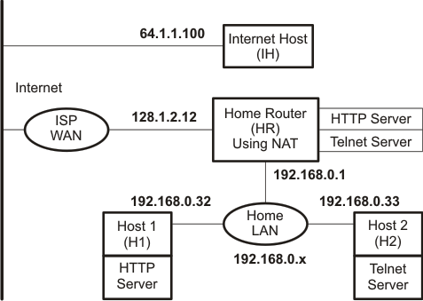

To make the servers on H1 and H2 public, the following NAT port mapping entries are installed on HR:

**NAT Entry Table**

| Foreign IP | Foreign Port | Local IP | Local Port | Mapped Port | IP Protocol | TCP State | Timeout |
| --- | --- | --- | --- | --- | --- | --- | --- |
| *wild* | *wild* | 192.168.0.33 | 23 | 23 | TCP | - | STATIC |
| *wild* | *wild* | 192.168.0.32 | 80 | 80 | TCP | - | STATIC |

With these mappings, the externally available HTTP server and Telnet server publicly accessible on the WAN IP (128.1.2.12) are actually executing on H1 and H2. However, HR can have its own HTTP and Telnet servers and make them available to hosts on the LAN.

Also note that, regardless of how hosts on the LAN access HR (either through 192.168.0.1 or 128.1.2.12), their packets are not processed via NAT. Thus, they are never altered. The following are some connection examples:

| Client | Protocol Used | Target Address | Resulting Server Connection |
| --- | --- | --- | --- |
| IH | HTTP | 128.1.2.12 | HTTP on H1 |
| H2 | HTTP | 128.1.2.12 | HTTP on HR |
| H2 | HTTP | 192.168.0.1 | HTTP on HR |
| H2 | HTTP | 192.168.0.32 | HTTP on H1 |
| IH | Telnet | 128.1.2.12 | Telnet on H2 |
| H1 | Telnet | 128.1.2.12 | Telnet on HR |
| H1 | Telnet | 192.168.0.1 | Telnet on HR |
| H1 | Telnet | 192.168.0.33 | Telnet on H2 |

### B.1.4 NAT Proxy Filters

### B.1.4.1 Problem Synopsis

Translating the IP destination address of a packet via NAT guarantees that all packets can be redirected to their correct physical destination, but it does not guarantee that the information will be understood by the recipient. Because one side of the connection always believes they are actually connected to a different IP address than their physical peer, there is a possibility that the application using the information will become confused. The confusion arises when there is information in the packet payload that is dependent on the IP address/port of the peer connection.

### B.1.4.2 Problem Example - FTP Clients on the LAN

As a straightforward example of a situation that requires a proxy filter, consider FTP (file transfer protocol). FTP actually uses two ports to transmit a file. The first port establishes the control connection. Then, new ports establish the data connection to actually send the file. The FTP protocol allows an FTP client to specify its port for the data connection to the server. If no port is specified by the client, the client’s control port value is used.

The above scenario presents a couple problems for standard NAT. First, if NAT creates an entry for the FTP control connection, the entry could not be used for the data connection. As an example, H1 sends an FTP connection request to IH. The packet would be addressed as follows:

**Packet 1**

| To | From | Protocol |
| --- | --- | --- |
| 64.1.1.100 : 21 | 192.168.0.32 : 1137 | TCP |

**NAT Entry Table**

| Foreign IP | Foreign Port | Local IP | Local Port | Mapped Port | IP Protocol | TCP State | Timeout |
| --- | --- | --- | --- | --- | --- | --- | --- |
| 64.1.1.100 | 21 | 192.168.0.32 | 1137 | 50003 | TCP | SYNSENT | 00:01:00 |

The modified packet and its reply would proceed as discussed in Section B.1.2. The modified packet would be:

**Packet 1 (modified)**

| To | From | Protocol |
| --- | --- | --- |
| 64.1.1.100 : 21 | 128.1.2.12 : 50003 | TCP |

Now assume that eventually the FTP server on IH attempts to establish a data connection back to what it thinks is the FTP client’s ephemeral port (50003). Note classic FTP uses port 20 to establish data connections. Its connection request packet would be:

**Packet 2 (Data connection request)**

| To | From | Protocol |
| --- | --- | --- |
| 128.1.2.12 : 50003 | 64.1.1.100 : 20 | TCP |

Because there is no NAT entry record that will match the address values in this packet (specifically port 20 in the *From* field), this packet will not be forwarded to the FTP client. For this to work, there must be a port mapping installed for 64.1.1.100 that has a wildcard port value (it is not certain that the connection request will arrive on port 20). The NAT entry table would be as follows:

**NAT Entry Table**

| Foreign IP | Foreign Port | Local IP | Local Port | Mapped Port | IP Protocol | TCP State | Timeout |
| --- | --- | --- | --- | --- | --- | --- | --- |
| 64.1.1.100 | *wild* | 192.168.0.32 | 1137 | 50003 | TCP | - | STATIC |
| 64.1.1.100 | 21 | 192.168.0.32 | 1137 | 50003 | TCP | CONNECT | 04:58:39 |

With such a mapping, if a connection request from port 20 arrived, the wild card entry would be matched, and another entry spawned for port 20 on IH. The table would look as follows:

| Foreign IP | Foreign Port | Local IP | Local Port | Mapped Port | IP Protocol | TCP State | Timeout |
| --- | --- | --- | --- | --- | --- | --- | --- |
| 64.1.1.100 | 20 | 192.168.0.32 | 1137 | 50003 | TCP | SYNSENT | 00:01:00 |
| 64.1.1.100 | *wild* | 192.168.0.32 | 1137 | 50003 | TCP | - | STATIC |
| 64.1.1.100 | 21 | 192.168.0.32 | 1137 | 50003 | TCP | CONNECT | 04:58:39 |

The second issue in dealing with an FTP client is that the client can change the port on which the FTP server attempts connection. This is done via a PORT command sent from the client to the server. The PORT command contains information about the client in the packet payload.

For example, assume the FTP client (H1) creates a new socket for the data connection, and its ephemeral port value is 1142. H1 would then send an FTP PORT command on the control connection to the server. The server would then attempt a connection. The following is an approximation of the operation (it is not the exact syntax of the port command).

**Packet 3 (FTP Client H1 Sends Port Command for Port 1142)**

| To | From | Protocol | Packet Payload |
| --- | --- | --- | --- |
| 64.1.1.100 : 21 | 192.168.0.32 : 1137 | TCP | “PORT 192.168.0.32, 1142” |

As a reminder, the FTP server would normally see the packet as:

**Packet 3 (modified incorrectly)**

| To | From | Protocol | Packet Payload |
| --- | --- | --- | --- |
| 64.1.1.100 : 21 | 128.1.2.12 : 50003 | TCP | “PORT 192.168.0.32, 1142” |

This packet creates a couple of problems. First, the IP address in the PORT command does not match the IP address of the FTP server’s connected peer. This would produce an error. Plus, the IP address in the PORT command is not a real Internet address. Lastly, even if the FTP server tried to connect to 128.1.2.12:1142, there is no mapping for the port number in the NAT entry table.

The correct procedure for modifying this packet is to solve all the above problems. First, a new NAT entry is created for 192.168.0.32:1142. The foreign IP address is left as a wildcard because as before, because it is not certain what port the FTP server will use. The NAT entry table would then look as follows:

**NAT Entry Table**

| Foreign IP | Foreign Port | Local IP | Local Port | Mapped Port | IP Protocol | TCP State | Timeout |
| --- | --- | --- | --- | --- | --- | --- | --- |
| 64.1.1.100 | *wild* | 192.168.0.32 | 1142 | 50004 | TCP | - | 00:02:00 |
| 64.1.1.100 | *wild* | 192.168.0.32 | 1137 | 50003 | TCP | - | STATIC |
| 64.1.1.100 | 21 | 192.168.0.32 | 1137 | 50003 | TCP | CONNECT | 04:58:39 |

To review, note that you have the original NAT entry for the FTP control connection, and now two wildcard entries for possible FTP data connection requests.

**Packet 3 (modified correctly)**

| To | From | Protocol | Packet Payload |
| --- | --- | --- | --- |
| 64.1.1.100 : 21 | 128.1.2.12 : 50003 | TCP | “PORT 128.1.2.12, 50004” |

It is also possible for a client to request the FTP server to create a new port (the PASV command), but that does not create any issues for FTP clients on the LAN. If the FTP server were on the LAN and the client on the WAN, the proxy process would key off the PASV command.